# CW1

## Coursework 1

#### Urte Adomaityte CID 01356309

#### This is my own work unless stated otherwise.

```python
import numpy as np
import pandas as pd
from scipy import stats
import random
import math
import matplotlib.pyplot as plt
```

### Task 1: Regression

### Loading and cleaning the regression data

#### Save and clean the train data

```python
header = ['col'+str(i) for i in range(19)]
data_train = pd.read_csv("regression_train.csv", names=header)
data_train.head(4)
```

|  | col0 | col1 | col2 | col3 | col4 | col5 | col6 | col7 | col8 | col9 | col10 | col11 | col12 | col13 | col14 | col15 | col16 | col17 | col18 |
| --- | --- | --- | --- | --- | --- | --- | --- | --- | --- | --- | --- | --- | --- | --- | --- | --- | --- | --- | --- |
| 0 | 1.0 | -0.413447 | -0.487722 | 0.115738 | 0.115735 | 0.158124 | 0.984960 | 0.797449 | -0.773684 | 0.985161 | -0.803212 | 1.176466 | 0.441052 | -0.983048 | 0.158124 | 1.176469 | -0.487723 | -0.773598 | 23.9 |
| 1 | 1.0 | -0.412788 | -0.487722 | -1.034027 | -1.034035 | -0.386091 | 0.819700 | 0.207144 | -0.418203 | 0.819617 | -0.666608 | -0.857929 | 0.379323 | -0.803625 | -0.386091 | -0.857939 | -0.487723 | -0.418305 | 29.9 |
| 2 | 1.0 | -0.387983 | -0.487722 | -0.211099 | -0.211084 | 0.261784 | -0.510932 | -0.923682 | -0.671859 | -0.511320 | -0.102376 | 0.344213 | 0.441052 | 0.131334 | 0.261784 | 0.344218 | -0.487727 | -0.671863 | 24.5 |
| 3 | 1.0 | -0.347952 | -0.487722 | -0.720322 | -0.720323 | -0.412006 | 0.846768 | 0.324494 | -0.248591 | 0.846699 | -0.601276 | -0.488039 | 0.369674 | -0.381702 | -0.412006 | -0.488023 | -0.487722 | -0.248524 | 27.5 |

Check for duplicate rows based on all columns, none found.

```python
dup = data_train.duplicated()
for i in range(len(dup)):
    if dup[i]==True:
        print('found duplicate at',i)

dup_rows = data_train[data_train.duplicated()]
print("Duplicate rows :")
print(dup_rows)
```

```
Duplicate rows :
Empty DataFrame
Columns: [col0, col1, col2, col3, col4, col5, col6, col7, col8, col9, col10, col11, col12, col13, col14, col15, col16, col17, col18]
Index: []
```

We investigate the data visually to see whether it needs to be standardised. Notice that the predictors seem to be normalised. We assume that the train and test set have the same distribution.

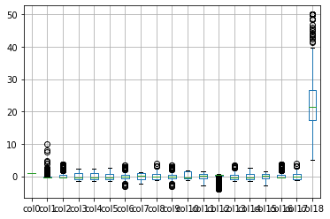

```python
# check for colinearity of the training set with a boxplot
header1 = ['col'+str(i) for i in range(19)]
boxplot = data_train.boxplot(header1)
```

Check for colinearity of the training set with a boxplot

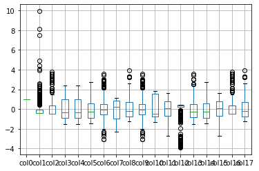

```python
header1 = ['col'+str(i) for i in range(18)]
boxplot = data_train.boxplot(header1)
```

Notice and print the collinear columns side-by-side

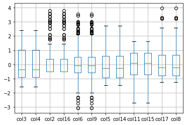

```python
header2 = ['col3','col4','col2','col16','col6','col9','col5','col14','col11','col15','col17','col8']
boxplot = data_train.boxplot(header2)
```

Notice that they are very similar in distribution - we will eliminate collinear columns and see if it linear regression works better with this dataset. The collumn elimination will be done when the data is turned into matrix (numpy array) form.

#### Test data

```python
data_test = pd.read_csv("regression_test.csv", names=header)
data_test.head(2)
```

|  | col0 | col1 | col2 | col3 | col4 | col5 | col6 | col7 | col8 | col9 | col10 | col11 | col12 | col13 | col14 | col15 | col16 | col17 | col18 |
| --- | --- | --- | --- | --- | --- | --- | --- | --- | --- | --- | --- | --- | --- | --- | --- | --- | --- | --- | --- |
| 0 | 1.0 | -0.405603 | 0.048772 | -0.739290 | -0.739279 | -1.258562 | -0.569343 | -1.265064 | 1.284902 | -0.568923 | -0.375583 | 0.205505 | 0.441052 | -0.541500 | -1.258562 | 0.205489 | 0.048770 | 1.284940 | 20.9 |
| 1 | 1.0 | -0.409965 | 1.443658 | -1.123032 | -1.123042 | -1.016689 | 0.949344 | -1.674010 | 1.276251 | 0.949281 | -0.060801 | -1.505237 | 0.230317 | -1.058741 | -1.016689 | -1.505250 | 1.443655 | 1.276197 | 37.0 |

Check the distribution visually, notice that it has a similar distribution to the train set - we are safe to assume they have the same distribution and it will make sense to use the function trained on the train set on the test set.

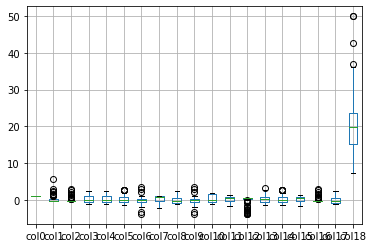

```python
header1 = ['col'+str(i) for i in range(19)]
boxplot = data_test.boxplot(header1)
```

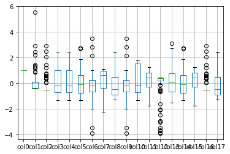

```python
# check for colinearity of the test set with a boxplot
header1 = ['col'+str(i) for i in range(18)]
boxplot = data_test.boxplot(header1)
```

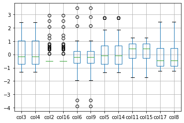

```python
# print out the collinear columns side-by-side
header2 = ['col3','col4','col2','col16','col6','col9','col5','col14','col11','col15','col17','col8']
boxplot = data_test.boxplot(header2)
```

Notice that here, too, the same colums are collinear. Eliminate them and see how linear regression performs with each train and test datasets.

#### 1.1 Linear Regression

##### 1.1.1.

We will obtain a linear regression model to predict the target variable: median value of owner-occupied homes in USD 1000's, stored in the last column of the dataset.

Then we will report parameters of the model and the in-sample mean squared error (MSE) from the training set.

```python
# get X (predictors) and y (target variable) for train and test from dataframes

# training set into matrix
arr_train = data_train.to_numpy()
# split it
X_train = arr_train[:,:-1]
y_train = arr_train[:,-1]
print('shape of matrix X containing training predictors',X_train.shape)
print('length of y_train',len(y_train))

# test set into matrix
arr_test = data_test.to_numpy()
# split it
X_test = arr_test[:,:-1]
y_test = arr_test[:,-1]

# eliminate the fourth column in train set and test set
X_train_elim = np.delete(X_train, [4,16,9,14,15,8], 1)
X_test_elim = np.delete(X_test, [4,16,9,14,15,8], 1)

print('Shape of the predictor matrices X_train and X_test after elimination of collinear columns')
print(X_train_elim.shape)
print(X_test_elim.shape)
```

```
shape of matrix X containing training predictors (404, 18)
length of y_train 404
Shape of the predictor matrices X_train and X_test after elimination of collinear columns
(404, 12)
(102, 12)
```

```python
# define maximum likelihood estimate for this training set
def max_lik_estimate(X, y):
    # X: N=404 x D=18 matrix of training inputs
    # y: N=404 x 1 vector of training targets/observations
    # returns: maximum likelihood parameters (D=18 x 1)
    N, D = X.shape
    beta_ml = np.linalg.solve(X.T @ X, X.T @ y)
    return beta_ml
```

We use the maximum liekelihood estimate to get the parameters beta of the model

```python
beta_ml = max_lik_estimate(X_train,y_train)
print('parameters beta of the model with collinear rows:\n',beta_ml)
```

```
parameters beta of the model with collinear rows:
 [ 2.25195147e+01 -6.18293247e-01 -4.49290005e+04 -4.00382415e+04
  4.00380821e+04  3.01999433e+02  9.82671082e+02 -1.58321469e-01
  1.37926982e+03 -9.79553073e+02 -5.46852187e-02 -5.67502440e+03
  7.41991548e-01 -3.71807163e+00 -3.03791933e+02  5.67328253e+03
  4.49301324e+04 -1.38276124e+03]
```

```python
# define the prediction function for linear regression
def predict_with_estimate(X_test, beta):
    # X_test: K x D matrix of test inputs
    # beta: D x 1 vector of parameters
    # returns: prediction of f(X_test); K x 1 vector
    prediction = X_test @ beta
    return prediction
```

Finally, we get the prediction and calculate the in-sample mean squared error (MSE)

```python
in_pred = predict_with_estimate(X_train, beta_ml)
mse_in = np.square(np.subtract(y_train,in_pred)).mean()
print('in-sample MSE, train set with collinear rows',mse_in)
```

```
in-sample MSE, train set with collinear rows 24.36924679184832
```

```python
# get maximum likelihood estimate - parameters of the model for the X_train with eliminated 4th row
beta_ml_elim = max_lik_estimate(X_train_elim,y_train)
print('Parameters beta of the model without collinear rows:\n',beta_ml_elim)
```

```
Parameters beta of the model without collinear rows:
 [22.52796322 -0.63690087  1.15237006 -0.19674719 -1.69697157  3.13055287
 -0.13692781 -0.08360849 -1.74357946  0.81728303 -3.66390957 -3.48789421]
```

```python
# in-sample MSE with eliminated (colinear) 4th row
in_pred_elim = predict_with_estimate(X_train_elim, beta_ml_elim)
mse_in_elim = np.square(np.subtract(y_train,in_pred_elim)).mean()
print('in-sample MSE, train set without collinear rows',mse_in_elim)
```

```
in-sample MSE, train set without collinear rows 24.553868836373788
```

Getting a MSE of around 24 makes sense when we look at the values of the dependent variable y_train, the last column in the full training dataset, as their mean is around 20 and the data points range from 7 to the largest outlier being 50. Moreover, a larger in-sample MSE having removed the collinear rows suggests a reduction in overfitting, so we will proceed to work with the removed columns.

As a plus, compute the condition numbers of the matrices with collinear columns and without collinear columns:

```python
X_cond = np.linalg.cond(X_train)
print('not eliminated',X_cond)
X_cond_e = np.linalg.cond(X_train_elim)
print('eliminated',X_cond_e)
```

```
not eliminated 1.5685751557079054e+16
eliminated 6.094416963408895
```

We now clearly see that the condition number of the training data with collinear columns is much larger. This shows that the taking the inverse $(X^T X)^{-1}$ which is needed in the solution for the beta terms in linear regression will result in larger variance.

We will explicitly check that when we evaluate whether the elimination reduces the out-of-sample error in the next subsection.

Now, check whether we can get a smaller error by standardising the data.

```python
# function to standardize X_train_elim and X_test_elim
def standardise(X):
    mu = np.mean(X, 0)
    sigma = np.std(X, 0)
    X_std = (X - mu) / sigma
    return X_std
```

```python
# standardise the data separately
X_train_st = np.delete(X_train_elim, 0, 1)  # delete the first column not to get nan
X_test_st = np.delete(X_test_elim, 0, 1)  # delete the first column not to get nan
X_train_st = standardise(X_train_st)
X_test_st = standardise(X_test_st)
# concatenate the first column back to capture the beta0
ones = np.ones((len(X_train_st),1))
X_train_st = np.hstack((ones,X_train_st))
ones = np.ones((len(X_test_st),1))
X_test_st = np.hstack((ones,X_test_st))

y_train_st = standardise(y_train)
y_test_st = standardise(y_test)
```

```python
# get maximum likelihood estimate - parameters of the model
beta_st = max_lik_estimate(X_train_st,y_train_st)
# print('parameters beta, standardised data:\n',beta_st)
# in-sample mean squared error (MSE)
in_pred = predict_with_estimate(X_train_st, beta_st)
mse_in = np.square(np.subtract(y_train_st,in_pred)).mean()
print('in-sample MSE for training set',mse_in)

# make a prediction using the MLE
out_pred = predict_with_estimate(X_test_st, beta_st)
# out-sample mean squared error (MSE)
mse_out = np.square(np.subtract(y_test_st,out_pred)).mean()
print('out-of-sample MSE for test set',mse_out)
```

```
in-sample MSE for training set 0.273472927326193
out-of-sample MSE for test set 0.3380837473894245
```

```python
# standardise the train data X and y TOGETHER
arr_train_st = data_train.to_numpy()
arr_train_st = np.delete(arr_train_st, 0, 1)  # delete the first column not to get nan
arr_train_st = standardise(arr_train_st)
# concatenate the first column back to capture the beta0
ones = np.ones((len(arr_train_st),1))
arr_train_st = np.hstack((ones,arr_train_st))

X_train_st = arr_train_st[:,:-1]
y_train_st = arr_train_st[:,-1]
# get maximum likelihood estimate - parameters of the model
beta_st = max_lik_estimate(X_train_st,y_train_st)
# print('parameters beta, standardised data:\n',beta_st)
# in-sample mean squared error (MSE)
in_pred = predict_with_estimate(X_train_st, beta_st)
mse_in = np.square(np.subtract(y_train_st,in_pred)).mean()
print(mse_in)


# standardise the test data X and y TOGETHER
arr_test_st = data_test.to_numpy()
arr_test_st = np.delete(arr_test_st, 0, 1)  # delete the first column not to get nan
arr_test_st = standardise(arr_test_st)
# concatenate the first column back to capture the beta0
ones = np.ones((len(arr_test_st),1))
arr_test_st = np.hstack((ones,arr_test_st))

X_test_st = arr_test_st[:,:-1]
y_test_st = arr_test_st[:,-1]

# make a prediction using the MLE
out_pred = predict_with_estimate(X_test_st, beta_st)
# out-sample mean squared error (MSE)
mse_out = np.square(np.subtract(y_test_st,out_pred)).mean()
print('out-of-sample MSE for test set with collinear columns',mse_out)
```

```
0.2714166676017768
out-of-sample MSE for test set with collinear columns 0.340311020497055
```

##### 1.1.2.

In this subsection, we will use the test data to test the model to predict the target variable, compute the out-of-sample MSE on the test set. We will then compare to the in-sample MSE and explain the differences.

```python
# make a prediction using the MLE
out_pred = predict_with_estimate(X_test, beta_ml)
# out-sample mean squared error (MSE)
mse_out = np.square(np.subtract(y_test,out_pred)).mean()
print('out-of-sample MSE for test set with collinear columns',mse_out)
```

```
out-of-sample MSE for test set with collinear columns 19.557330193706065
```

```python
# out-sample MSE, eliminated colinear columns
out_pred_elim = predict_with_estimate(X_test_elim, beta_ml_elim)
mse_out_elim = np.square(np.subtract(y_test,out_pred_elim)).mean()
print('out-of-sample MSE for test set, eliminated collinear columns:',mse_out_elim)
```

```
out-of-sample MSE for test set, eliminated collinear columns: 19.360481532901694
```

The first observation is that the out-of-sample MSE for both matrices is smaller than the in-sample MSE. This is arguably because we have less rows in the test set than the train set and the model works better.

Moreover, we know that collinearity produces overfitting and we see that indeed for the train and test sets with all columns (some of which are collinear), we have a smaller in-sample MSE and a larger out-of-sample MSE than for the train and test sets where we eliminate the collinear columns. This shows that the model trained with collinear columns tends to overfit and has errors due to the large condition number of the training matrix. It is also nicer because in addition to getting more accurate predictions, we have less data to train on - the computations are faster.

#### 1.2 Ridge Regression

Report the values of the penalty parameter obtained for the five folds.

We start by eliminating the collinear columns as we have seen they produce better results in the previous part (less overfitting).

```python
# eliminate collinear columns for good
print('Shape of X_train before elimination',X_train.shape)
print('Shape of X_test before elimination',X_test.shape)

X_train = np.delete(X_train, [4,16,9,14,15,8], 1)
X_test = np.delete(X_test, [4,16,9,14,15,8], 1)

print('Shape of X_train after elimination',X_train.shape)
print('Shape of X_test after elimination',X_test.shape)
```

```
Shape of X_train before elimination (404, 18)
Shape of X_test before elimination (102, 18)
Shape of X_train after elimination (404, 12)
Shape of X_test after elimination (102, 12)
```

Define the function that computes maximum likelihood parameters.

```python
def ridge_estimate(X, y, penalty):
    # X: N x D matrix of training inputs
    # y: N x 1 vector of training targets/observations
    # returns: maximum likelihood parameters (D x 1)
    N, D = X.shape
    I = np.identity(D)
    beta_ridge = np.linalg.solve(X.T @ X + penalty * I, X.T @ y)
    return beta_ridge
```

Define the functions that will allow us to do the splitting into folds and evaluate the model.

```python
def cross_val_split(data, num_folds):
    fold_size = int(len(data) / num_folds)
    data_perm = np.random.RandomState(seed=1007).permutation(data) # set the seed to always have the same random permutations
    folds = []
    for k in range(num_folds):
        folds.append(data_perm[k*fold_size:(k+1)*fold_size, :])
    return folds
```

```python
def cross_val_evaluate(data, num_folds, penalty_term, X_test, y_test):  # the y_test needs to be shuffled the same as the folds

    folds = cross_val_split(data, num_folds)

    # define this list for each penalty term, it collects the 5 MSEs
    val_mses = []
    test_mses = []

    for i in range(len(folds)):
        # define the training set
        train_set = np.delete(np.asarray(folds).reshape(len(folds), folds[0].shape[0], folds[0].shape[1]), i, axis=0)
        train_folds = train_set.reshape(len(train_set)*train_set[0].shape[0], train_set[0].shape[1])

        X_train = train_folds[:,:-1]
        y_train = train_folds[:,-1]

        # define the validation set
        val_fold = folds[i]
        X_val = val_fold[:,:-1]
        y_val = val_fold[:,-1]

        # train on all folds except k with penalty p - get beta_ridge
        beta_ridge = ridge_estimate(X_train, y_train, penalty=penalty_term)

        # calculate prediction on fold k with penalty p - get ridge_prediction
        ridge_prediction_val = predict_with_estimate(X_val, beta_ridge)
        # evaluate the MSE on the validation set
        val_mse = np.square(np.subtract(y_val,ridge_prediction_val)).mean()

        # append the validation MSE to the list containing the MSEs for each fold
        val_mses.append(val_mse)

        # calculate prediction for test set, evaluate the MSE on the test set
        ridge_prediction_test = predict_with_estimate(X_test, beta_ridge)
        test_mse = np.square(np.subtract(y_test,ridge_prediction_test)).mean()
        test_mses.append(test_mse) # append

    return np.array(val_mses), np.array(test_mses)
```

```python
print(X_train.shape)
print(y_train.shape)
y_train = (np.zeros((1,404))+y_train).T
print(y_train.shape)

# stack the X and y train together so that permutation does not violate the correspondence of the predictors and outcome
data1 = np.hstack((X_train,y_train))
print(data1.shape)

# y_test = (np.zeros((1,102))+y_test).T
# data_test = np.hstack((X_test,y_test))
```

```
(404, 12)
(404,)
(404, 1)
(404, 13)
```

Scan over penalty parameters, save the validation MSEs in a matrix with rows corresponding to each candidate parameter, and 5 columns corresponding to each of the 5 validation folds. The number of columns is therefore 5 in our case.

```python
# candidate penalty terms
p_term = np.arange(0.0,28,0.01)

ERR_val = np.zeros((len(p_term),5))
ERR_test = np.zeros((len(p_term),5))

# shuffle the data (X and y stacked together)
data_ridge = data1.copy()
random.seed(1007)
random.shuffle(data_ridge)


# fill the MSE matrix
p_i=0
for p in p_term:
    val_mses, test_mses = cross_val_evaluate(data_ridge, 5, p, X_test, y_test)
    ERR_val[p_i,:] = val_mses
    ERR_test[p_i,:] = test_mses
    p_i+=1

print('Shape of the matrix containing the MSEs for each fold for each candidate penalty term',ERR_val.shape)
```

```
Shape of the matrix containing the MSEs for each fold for each candidate penalty term (2800, 5)
```

Get optimal penalty terms, plot for the first fold

```
Minimal value of validation MSE, fold 1: 32.17310161113137
Optimal penalty term validation fold 1: 0.0
```

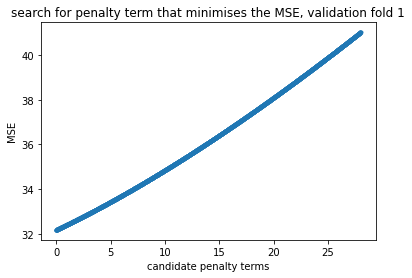

```
Minimal value of validation MSE, fold 2: 11.773948995352871
Optimal penalty term validation fold 2: 13.030000000000001

Minimal value of validation MSE, fold 3: 18.78405850427335
Optimal penalty term validation fold 3: 11.01

Minimal value of validation MSE, fold 4: 33.87176873784628
Optimal penalty term validation fold 4: 0.0

Minimal value of validation MSE, fold 5: 25.420508858164368
Optimal penalty term validation fold 5: 1.67

Optimal penalty parameter for each 5-fold [0.0, 13.030000000000001, 11.01, 0.0, 1.67]
```

```python
def get_optimal_penalty(ERR,p_term,val_fold_index):
    mse_fold = ERR[:,val_fold_index]

    minp1=np.min(mse_fold)
    print('Minimal value of validation MSE, fold '+str(val_fold_index+1)+':', minp1)

    opt_p = p_term[np.argmin(mse_fold)]
    print('Optimal penalty term validation fold '+str(val_fold_index+1)+':',opt_p,'\n')
    if val_fold_index==0:
        plt.plot(p_term,mse_fold,'.')
        plt.title('search for penalty term that minimises the MSE, validation fold 1')
        plt.xlabel('candidate penalty terms')
        plt.ylabel('MSE')
        plt.show()
    return opt_p

p_optimal = []
for i in range(5):
    p1 = get_optimal_penalty(ERR_val,p_term,i)
    p_optimal.append(p1)

print('Optimal penalty parameter for each 5-fold',p_optimal)
```

##### 1.2.2.

Compute average in-sample MSE (using validation MSE):

1) Compute the MSE of each validation fold for each candidate penalty term

2) Take the average of these MSEs to get the average MSE for the specific candidate penalty term

3) Choose the optimal penalty where the average MSE is minimum across all candidate penalty terms

```
Average in-sample validation MSE over 5 folds

Minimum value of validation MSE 24.754479641205048

Optimal penalty term 0.39
```

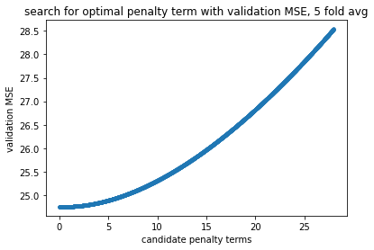

```python
# calculate the average validation MSE over the 5 folds for each candidate penalty term
mse_avg_val = (1/5)*ERR_val.sum(axis=1)

# find the optimal penalty term to get the smallest average MSE over the 5 folds
minp_in=np.min(mse_avg_val)
print('Average in-sample validation MSE over 5 folds\n\nMinimum value of validation MSE',minp_in)
# print('\nminimum at index',np.argmin(mse_avg))
p_opt = p_term[np.argmin(mse_avg_val)]
print('\nOptimal penalty term',p_opt)
plt.plot(p_term,mse_avg_val,'.')
plt.title('search for optimal penalty term with validation MSE, 5 fold avg')
plt.xlabel('candidate penalty terms')
plt.ylabel('validation MSE')
plt.show()
```

Compute the out-of-sample MSE with this optimal penalty term that we got from the evaluation of the average in-sample MSE:

```python
# train the model with this 'optimal' training parameter
beta_ridge1 = ridge_estimate(X_train, y_train, penalty=p_opt)
# calculate prediction on training set
ridge_prediction1 = predict_with_estimate(X_train, beta_ridge1)
# evaluate the MSE on the train set
in_mse1 = np.square(np.subtract(y_train,ridge_prediction1)).mean()
print(in_mse1)


# train the model with this 'optimal' training parameter
beta_ridge2 = ridge_estimate(X_test, y_test, penalty=p_opt)
# calculate prediction on test set
ridge_prediction2 = predict_with_estimate(X_test, beta_ridge1)
# evaluate the MSE on the test set
in_mse2 = np.square(np.subtract(y_test,ridge_prediction2)).mean()
print(in_mse2)
```

```
24.55442531773087
107.60476132137794
```

Compute average out-of-sample MSE using the test set, averaged over the 5 folds:

```
Average out-of-sample MSE over 5 folds:

Minimum value of test MSE 19.17294737005144

Optimal penalty term 0.3
```

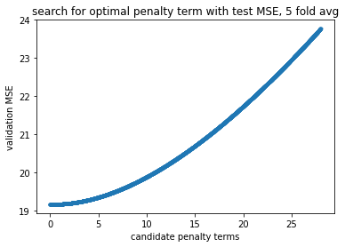

```python
# calculate the average test MSE over the 5 folds for each candidate penalty term
mse_avg_test = (1/5)*ERR_test.sum(axis=1)
# find the optimal penalty term to get the smallest average MSE over the 5 folds
minp_out=np.min(mse_avg_test)
print('Average out-of-sample MSE over 5 folds:\n\nMinimum value of test MSE',minp_out)
# print('\nminimum at index',np.argmin(mse_avg))
p_opt1 = p_term[np.argmin(mse_avg_test)]
print('\nOptimal penalty term',p_opt1)
plt.plot(p_term,mse_avg_test,'.')
plt.title('search for optimal penalty term with test MSE, 5 fold avg')
plt.xlabel('candidate penalty terms')
plt.ylabel('validation MSE')
plt.show()
```

```python
# train the model with this 'optimal' training parameter
beta_ridge1 = ridge_estimate(X_train, y_train, penalty=p_opt1)
# calculate prediction on training set
ridge_prediction1 = predict_with_estimate(X_train, beta_ridge1)
# evaluate the MSE on the train set
in_mse1 = np.square(np.subtract(y_train,ridge_prediction1)).mean()
print(in_mse1)


# calculate prediction on test set
ridge_prediction2 = predict_with_estimate(X_test, beta_ridge1)
# evaluate the MSE on the test set
in_mse2 = np.square(np.subtract(y_test,ridge_prediction2)).mean()
print(in_mse2)
```

```
24.554198350978666
107.61118556684289
```

Comparison with the linear regression MSE values:

```python
# in-sample MSE (averaged over the 5-fold validation sets from X_train)
print('Average in-sample MSE over the 5 folds (y_validation-y_pred):')
print('optimal penalty term:',p_opt)
print('\nin-sample MSE Ridge regression',minp_in)
print('in-sample MSE linear regression',mse_in_elim)


# out-of-sample MSE (with test set X_test, y_test)
print('\nAverage out-of-sample MSE over the 5 folds (y_test-y_pred):')
print('optimal penalty term:',p_opt1)
print('\nout-of-sample MSE Ridge regression',minp_out)
print('out-of-sample MSE linear regression',mse_out_elim)
```

```
Average in-sample MSE over the 5 folds (y_validation-y_pred):
optimal penalty term: 0.39

in-sample MSE Ridge regression 24.754479641205048
in-sample MSE linear regression 24.553868836373788

Average out-of-sample MSE over the 5 folds (y_test-y_pred):
optimal penalty term: 0.3

out-of-sample MSE Ridge regression 19.17294737005144
out-of-sample MSE linear regression 19.360481532901694
```

In-sample: using Ridge regression, we get a larger in-sample MSE than linear regression in part 1.1.2.

Out-of-sample: using Ridge regression, we get a slightly smaller out-of-sample MSE than linear regression in part 1.1.2.

This clearly shows that Ridge regression indeed reduces overfitting that we get with linear regression. This is because compared to linear regression, Ridge is a bit worse (larger MSE) for the train set and, crucially, performs better on an unseen test set (smaller MSE). However, even though it is an improvement, it is not as significant as we would expect.

#### 1.3 Regression with kNN

##### 1.3.1.

Recall that the dataset we are using has the collinear columns eliminated so as to reduce overfitting - this is also valid for kNN because when we have collinear predictors (columns), the values in the predictor are close to each other and this will lead to smaller k values, which implies overfitting.

First, we define the functions we will use to implement the kNN algorithm.

```python
def euclidian_distance(p, q):
    return np.sqrt(np.sum((p-q)**2, axis=1))


def k_neighbours(X_test, X_train_stack, k, return_distance=False):
  n_neighbours = k
  dist = []
  neigh_ind = []

  # compute distance from each point x_text in X_test to all points in X_train (hint: use python's list comprehension)
  point_dist = [euclidian_distance(x_test, X_train_stack) for x_test in X_test]

  # determine which k training points are closest to each test point
  for row in point_dist:
      enum_neigh = enumerate(row)
      sorted_neigh = sorted(enum_neigh, key=lambda x: x[1])[:k]

      ind_list = [tup[0] for tup in sorted_neigh]
      dist_list = [tup[1] for tup in sorted_neigh]

      dist.append(dist_list)
      neigh_ind.append(ind_list)

  # return distances together with indices of k nearest neighbouts
  if return_distance:
      return np.array(dist), np.array(neigh_ind)

  return np.array(neigh_ind)


def reg_predict(X_test, y_train, X_train_stack, k):
  # each of the k neighbours contributes equally to the classification of any data point in X_test
  neighbours = k_neighbours(X_test, X_train_stack, k)
  # compute mean over neighbours labels (hint: use python's list comprehension)
  y_pred = np.array([np.mean(y_train[neighbour]) for neighbour in neighbours])
  return y_pred


def r2_score(y_test, y_pred):
  numerator = np.sum((y_test - y_pred)**2)
  y_avg = np.mean(y_test)
  denominator = np.sum((y_test - y_avg)**2)
  return 1 - numerator/denominator
```

In the cross-validation, we save the R2 error, the average in-sample and out-of-sample MSEs in matrices of the same form as in the CV for Ridge regression. The rows represent the candidate parameters, and the columns represent the folds over which we train the training data for that candidate parameter.

```python
k_arr = np.arange(1,20)  # candidate k's

def cross_val_evaluate(data, num_folds):

    folds = cross_val_split(data, num_folds)
    k_arr = np.arange(1,20)  # candidate k's
    print('candidate ks:',k_arr)

    R2 = np.zeros((len(k_arr),5))  # matrix to contain the r2 scores
    ERR_in = np.zeros((len(k_arr),5))  # to contain the validation MSEs
    ERR_out = np.zeros((len(k_arr),5)) # for out-of-sample MSEs


    for i in range(len(folds)):
#         print('Fold', i+1)
        # define the training set
        train_set = np.delete(np.asarray(folds).reshape(len(folds), folds[0].shape[0], folds[0].shape[1]), i, axis=0)
        train_folds = train_set.reshape(len(train_set)*train_set[0].shape[0], train_set[0].shape[1])
        X_train = train_folds[:,:-1]
        y_train = train_folds[:,-1]

        # define the validation set
        val_fold = folds[i]
        X_val = val_fold[:,:-1]
        y_val = val_fold[:,-1]

        # iterate through the k's
        j=0  # row index for each candidate k
        for k in k_arr:
            # predict on validation set
            y_pred = reg_predict(X_val, y_train, X_train, k)  # get prediction for knn-neighbors for train set without fold i
            # R2 score
            r2 = r2_score(y_val, y_pred)  # calculate the r2 score for knn-neighbors for fold i as validation set
            R2[j,i] = r2
            # validation MSE in-sample
            mse_in = np.square(np.subtract(y_val,y_pred)).mean()
            ERR_in[j,i] = mse_in

            # predict on the test set, out-of-sample
            y_pred = reg_predict(X_test, y_train, X_train, k)
            mse_out = np.square(np.subtract(y_test,y_pred)).mean()
            ERR_out[j,i] = mse_out
            j+=1

    return R2, ERR_in, ERR_out
```

```python
# shuffle the data (X and y stacked together)
data_perm = data1.copy()
random.seed(1007)
random.shuffle(data_perm)

R2, ERR_in, ERR_out = cross_val_evaluate(data_perm, 5)
```

```
candidate ks: [ 1  2  3  4  5  6  7  8  9 10 11 12 13 14 15 16 17 18 19]
```

```python
# check the sizes of the matrices
print('Shape of the matrix containing the errors (R2 scores)',R2.shape)
print('Shape of the matrix containing the in-sample MSEs for each fold for each candidate k',ERR_in.shape)
print('Shape of out-of sample MSEs',ERR_out.shape)
```

```
Shape of the matrix containing the errors (R2 scores) (19, 5)
Shape of the matrix containing the in-sample MSEs for each fold for each candidate k (19, 5)
Shape of out-of sample MSEs (19, 5)
```

We plot the three kinds of errors: R2 score, in-sample average MSE and out-of-sample average MSE over all 5 folds to see their behaviour

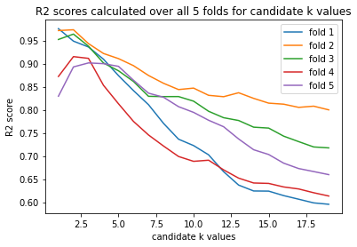

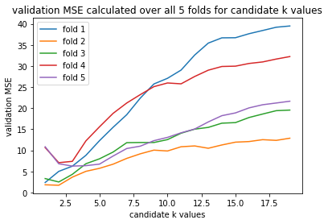

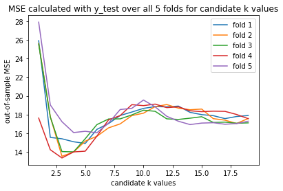

```python
# plot the R2 scores for each fold
for j in range(5):
    plt.plot(k_arr,R2[:,j], label='fold '+str(j+1))
plt.xlabel('candidate k values')
plt.ylabel('R2 score')
plt.title('R2 scores calculated over all 5 folds for candidate k values')
plt.legend()
plt.show()

# plot the validation MSE for each fold
for j in range(5):
    plt.plot(k_arr,ERR_in[:,j], label='fold '+str(j+1))
plt.xlabel('candidate k values')
plt.ylabel('validation MSE')
plt.title('validation MSE calculated over all 5 folds for candidate k values')
plt.legend()
plt.show()

for j in range(5):
    plt.plot(k_arr,ERR_out[:,j], label='fold '+str(j+1))
plt.xlabel('candidate k values')
plt.ylabel('out-of-sample MSE')
plt.title('MSE calculated with y_test over all 5 folds for candidate k values')
plt.legend()
plt.show()
```

Notice that the error is largest ar k=1 for the test data, this is consistent with the assertion that we have strong overfitting at small values of k (more analysis on that to follow later).

```python
# find optimal k values for each fold using R2 score
k_opt_arr = []
for i in range(5):
        k_opt = k_arr[np.argmax(R2[:,i])]
        k_opt_arr.append(k_opt)
print('List of optimal k values for each fold (using R2 score):', k_opt_arr)
```

```
List of optimal k values for each fold (using R2 score): [1, 2, 2, 2, 3]
```

Find optimal k for folds and show plot of errors for one of the folds:

```
Optimal k for fold 3 calculated with R2 score is k = 2
```

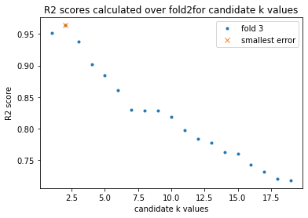

[output not shown]

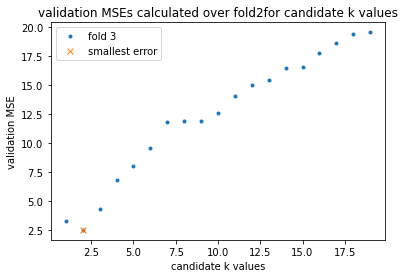

```python
# get maximum value of R2 score
fold_index = 2

k_opt3 = k_arr[np.argmax(R2[:,fold_index])]
print('Optimal k for fold 3 calculated with R2 score is k =',k_opt3)
plt.plot(k_arr,R2[:,fold_index],'.', label='fold 3')
plt.plot(k_opt3,R2[k_opt3-1,fold_index],'x',label='smallest error')
plt.xlabel('candidate k values')
plt.ylabel('R2 score')
plt.title('R2 scores calculated over fold '+str(fold_index)+' for candidate k values')
plt.legend()
plt.show()

# get minimum value of MSE
k_opt3 = k_arr[np.argmin(ERR_in[:,fold_index])]
print('Optimal k for fold 2 calculated with validation MSE is k =',k_opt3)
plt.plot(k_arr,ERR_in[:,fold_index],'.', label='fold 3')
plt.plot(k_opt3,ERR_in[k_opt3-1,fold_index],'x',label='smallest error')
plt.xlabel('candidate k values')
plt.ylabel('validation MSE')
plt.title('validation MSEs calculated over fold '+str(fold_index)+' for candidate k values')
plt.legend()
plt.show()
```

The optimal k calculated using the MSE for this fold and the R2 score (errors) for this fold is the same. We see explicitly that these criteria for optimising the hyperparameter are equivalent.

##### 1.3.2.

We now analyse the in-sample and out-of-sample MSE to determine the optimal k:

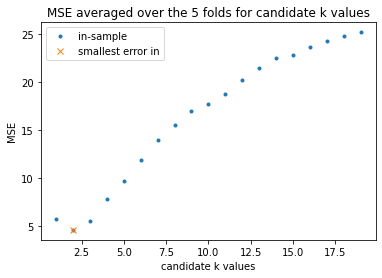

```
Minimal in-sample MSE at optimal k = 2 , averaged over the 5 folds: 4.61993125
```

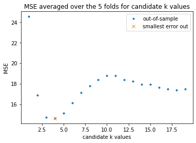

```
Minimal out-of-sample MSE at optimal k = 4 , averaged over the 5 folds: 14.627162990196078
```

```python
# in-sample validation MSE
mse_avg_in = (1/5)*ERR_in.sum(axis=1)  # get the average over the 5 folds of the ERR_val matrix
# get minimum k over the avg of five folds
k_opt_mse_in = k_arr[np.argmin(mse_avg_in)]

plt.plot(k_arr,mse_avg_in,'.',label='in-sample')
plt.plot(k_opt_mse_in,mse_avg_in[k_opt_mse_in-1],'x',label='smallest error in')
plt.xlabel('candidate k values')
plt.ylabel('MSE')
plt.title('MSE averaged over the 5 folds for candidate k values')
plt.legend()
plt.show()
print('\nMinimal in-sample MSE at optimal k =',k_opt_mse_in,', averaged over the 5 folds:',mse_avg_in[k_opt_mse_in-1])


# out-of-sample MSE
mse_avg_out = (1/5)*ERR_out.sum(axis=1)  # get the average over the 5 folds of the ERR_out matrix
k_opt_mse_out = k_arr[np.argmin(mse_avg_out)]
plt.plot(k_arr,mse_avg_out,'.',label='out-of-sample')
plt.plot(k_opt_mse_out,mse_avg_out[k_opt_mse_out-1],'x',label='smallest error out')
plt.xlabel('candidate k values')
plt.ylabel('MSE')
plt.title('MSE averaged over the 5 folds for candidate k values')
plt.legend()
plt.show()
print('Minimal out-of-sample MSE at optimal k =',k_opt_mse_out,', averaged over the 5 folds:',mse_avg_out[k_opt_mse_out-1])
```

This is significantly better than the linear or Ridge regression, importantly, there is a reduction from 19.17 to 14.627 in the out-of-sample MSE. Note that the kNN can reduce overfitting, for a suitable choice of k.

We get the relatively small optimal k=2 in the in-sample MSE, because the training set has been memorised in this case and we have overfitted the data, clearly having k=2 results in overfitting in the out-of-sample MSE. Even more so if we choose k=1, where the out-of-sample MSE is largest. This, again, is because we have high accuracy but high variance.

As we increase k seekin glower variance, we are tweaking the bias-variance balance and get lower accuracy (higher bias). This is reflected in the increasing in-sample MSE values as we increase k. However, looking at the out-of-sample MSE, we see that it is significantly smaller for k=3,4,5 than for k=1,2, suggesting we are decreasing the variance (at the cost of bias/accuracy). Our cross-validation results suggest that the optimal parameter k that minimises the out-of-sample MSE is k=4.

Therefore, I would take k=3 or k=4 for a reasonable bias-variance balance. Let us check whether these values of k are indeed the optimal for the testing set.

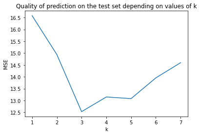

```python
# Let us check the MSE for varying values of k on the test set
mse = []
for k in range(1,8):
    y_knn = reg_predict(X_test, y_train, X_train, k)
    mse_out = np.square(np.subtract(y_test,y_knn)).mean()
    mse.append(mse_out)
plt.plot(range(1,8),mse)
plt.title('Quality of prediction on the test set depending on values of k')
plt.xlabel('k')
plt.ylabel('MSE')
plt.show()
```

```python
min_k = np.argmin(mse)
print('The minimal value of the MSE for the test set is',mse[min_k],'at k =',min_k+1)
```

```
The minimal value of the MSE for the test set is 12.530446623093683 at k = 3
```

Moreover, if we had not cleaned the data from collinear columns, we probably have gotten a smaller value of k as optimal foro the training set, which would lead to overfitting as the data would be more clustered in this case. This justifies removing the collinear columns.

## Task 2: Classification

### Loading and cleaning the classification dataset

#### Save the data

```python
# Train data
header = ['col'+str(i) for i in range(12)]
data_train = pd.read_csv("classification_train.csv", names=header)
data_train.head(3)
```

|  | col0 | col1 | col2 | col3 | col4 | col5 | col6 | col7 | col8 | col9 | col10 | col11 |
| --- | --- | --- | --- | --- | --- | --- | --- | --- | --- | --- | --- | --- |
| 0 | 0.161765 | 0.25 | 0.363156 | 0.25 | 0.0 | 0.000000 | 0.333333 | 0.333333 | 0.267857 | 1.000000 | 1.0 | 0.0 |
| 1 | 0.470588 | 0.50 | 0.858754 | 0.00 | 0.0 | 0.333333 | 0.666667 | 0.666667 | 0.428571 | 1.000000 | 0.0 | 1.0 |
| 2 | 0.117647 | 0.00 | 0.138054 | 0.00 | 1.0 | 0.333333 | 1.000000 | 0.333333 | 0.267857 | 0.666667 | 0.0 | 1.0 |

```python
# check for duplicate rows, none found
dup = data_train.duplicated()
for i in range(len(dup)):
    if dup[i]==True:
        print('found duplicate at',i)

dup_rows = data_train[data_train.duplicated()]
print("Duplicate rows dataframe:")
print(dup_rows)
```

```
Duplicate rows dataframe:
Empty DataFrame
Columns: [col0, col1, col2, col3, col4, col5, col6, col7, col8, col9, col10, col11]
Index: []
```

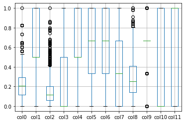

```python
# check for collinearity with a boxplot
header1 = ['col'+str(i) for i in range(12)]
boxplot = data_train.boxplot(header1)
```

Columns 5 and 6 look colinear, remove them

```python
# Test data
data_test = pd.read_csv("classification_test.csv", names=header)
data_test.head(2)
```

|  | col0 | col1 | col2 | col3 | col4 | col5 | col6 | col7 | col8 | col9 | col10 | col11 |
| --- | --- | --- | --- | --- | --- | --- | --- | --- | --- | --- | --- | --- |
| 0 | 0.205882 | 0.5 | 0.069055 | 0.0 | 0.5 | 1.000000 | 0.333333 | 1.0 | 0.232143 | 1.000000 | 1.0 | 1.0 |
| 1 | 0.382353 | 0.0 | 0.238418 | 0.0 | 0.5 | 0.333333 | 0.333333 | 0.0 | 0.232143 | 0.666667 | 0.0 | 1.0 |

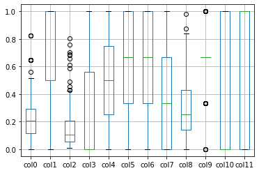

```python
# check for colinearity with a boxplot
header1 = ['col'+str(i) for i in range(12)]
boxplot = data_test.boxplot(header1)
```

Column 5 and column 6 look colinear, we need to eliminate them

```python
# get X (predictors) and y (target variable) for train and test from dataframes
print('N =',len(data_train))
```

```
N = 800
```

```python
# training set into matrix
arr_train = data_train.to_numpy()
print('full dataset size',arr_train.shape)
# eliminate the sixth column in train set
arr_train = np.delete(arr_train, 6, 1)
# shuffle it with the same seed
random.seed(1007)
random.shuffle(arr_train)
# split it
X_train = arr_train[:,:-1].T
y_train = arr_train[:,-1]

print('shape of matrix X containing training predictors',X_train.shape)
print('length of y_train',len(y_train))

# test set into matrix
arr_test = data_test.to_numpy()
# eliminate the sixth column in train set and test set
arr_test = np.delete(arr_test, 6, 1)
# shuffle it with same seed
random.seed(1007)
random.shuffle(arr_test)
# split it
X_test = arr_test[:,:-1].T
y_test = arr_test[:,-1]


print('\nshapes of X_train and X_test:\n',X_train.shape)
print(X_test.shape)
```

```
full dataset size (800, 12)
shape of matrix X containing training predictors (10, 800)
length of y_train 800

shapes of X_train and X_test:
 (10, 800)
(10, 200)
```

Our data set that has features over different ranges: we must standardise

```python
# standardize the X_train and X_test
def standardise(X):
  mu = np.mean(X, 0)
  sigma = np.std(X, 0)
  X_std = (X - mu) / sigma
  return X_std

X_train = standardise(X_train)
X_test = standardise(X_test)
```

#### 2.1. Logistic Regression

##### 2.1.1.

In this subsection, we implement logistic regression for classification with gradient descent for 5000 iterations; and perform a grid-search with 5-fold cross validation to find optimal set of hyperparameters: learning rate and decision threshold.

First, we define the functions to implement the logistic regression model.

```python
# define the functions we will need in this part for logistic regression
def logistic(x):
    return 1 / (1 + np.exp(-x))


def predict_log(X, beta, beta_0):
    y_log = logistic(beta.T @ X + beta_0)
    return y_log


def initialise(d):
    beta = np.zeros(shape=(d, 1), dtype=np.float32)
    beta_0 = 0
    assert(beta.shape==(d, 1))
    assert(isinstance(beta_0, float) or isinstance(beta_0, int))
    return beta, beta_0


def propagate(X, y, beta, beta_0):
    n = X.shape[1]
    y_log = predict_log(X, beta, beta_0)

    # cost function
    cost = (-1) * np.mean(np.multiply(y, np.log(y_log)) + np.multiply(1-y, np.log(1 - y_log)), axis=1)

    # derivatives
    dbeta = (1/n) * X @ np.transpose(y_log - y)
    dbeta_0 =  np.mean((y_log - y))

    assert(dbeta.shape==beta.shape)
    assert(dbeta_0.dtype==float)
    cost = np.squeeze(cost)
    assert(cost.shape==())

    # store gradients in a dictionary
    grads = {"dbeta": dbeta, "dbeta_0": dbeta_0}

    return grads, cost


def optimise(X, y, beta, beta_0, num_iterations=1000, learning_rate=0.005, print_cost=False):
    costs = []
    for i in range(num_iterations):

        # calculate cost and gradients
        grads, cost = propagate(X, y, beta, beta_0)

        # retrieve derivatives from grads
        dbeta = grads["dbeta"]
        dbeta_0 = grads["dbeta_0"]

        # updating procedure
        beta = beta - learning_rate * dbeta
        beta_0 = beta_0 - learning_rate * dbeta_0

        if i % 100 == 0:
            costs.append(cost) # append the cost

        # print the cost every 100 iterations
        if print_cost and i % 100 == 0:
            print ("cost after iteration %i: %f" %(i, cost))

    # save parameters and gradients in dictionary
    params = {"beta": beta, "beta_0": beta_0}
    grads = {"dbeta": dbeta, "dbeta_0": dbeta_0}

    return params, grads, costs
```

```python
# function to predict the classification labels
def predict(X_test, beta, beta_0, decision_threshold):
  n = X_test.shape[1]
  y_pred = np.zeros((1,n))
  beta = beta.reshape(X_test.shape[0], 1)

  # compute vector y_log predicting the probabilities
  y_log = predict_log(X_test, beta, beta_0)

  for i in range(y_log.shape[1]):
      # convert probabilities y_log to actual predictions y_pred
      if y_log[0, i] > decision_threshold:
          y_pred[0, i] = 1
      else:
          y_pred[0, i] = 0

  assert(y_pred.shape==(1, n))
  return y_pred


# define model
def model(X_train, y_train, X_test, y_test, decision_threshold, learning_rate, num_iterations=2000, print_cost=False, print_acc=False):
  # initialize parameters with zeros
  beta, beta_0 = initialise(X_train.shape[0])

  # gradient descent
  parameters, grads, costs = optimise(X_train, y_train, beta, beta_0, num_iterations, learning_rate, print_cost=print_cost)

  # retrieve parameters beta and beta_0 from dictionary "parameters"
  beta = parameters["beta"]
  beta_0 = parameters["beta_0"]

  # predict test and train set examples
  y_pred_test = predict(X_test, beta, beta_0, decision_threshold)
  y_pred_train = predict(X_train, beta, beta_0, decision_threshold)

  # print train/test Errors
  train_acc = 100 - np.mean(np.abs(y_pred_train - y_train)) * 100
  test_acc = 100 - np.mean(np.abs(y_pred_test - y_test)) * 100
  if print_acc:
    print("train accuracy: {} %".format(train_acc))
    print("test accuracy: {} %".format(test_acc))

  # saving all information
  d = {"costs": costs, "y_pred_test": y_pred_test, "y_pred_train": y_pred_train, "beta": beta, "beta_0": beta_0, "learning_rate": learning_rate, "num_iterations": num_iterations, "train_acc": train_acc, "test_acc": test_acc}

  return d
```

Investigate the sensitivity of the model to slight variations in the decision threshold and learning rate.

```python
print(X_train.shape)
print(y_train.shape)
print(X_test.shape)
print(y_test.shape)
d1 = model(X_train, y_train, X_test, y_test, 0.5, 0.001, num_iterations=5000, print_acc=True)
d4 = model(X_train, y_train, X_test, y_test, 0.4, 0.001, num_iterations=5000, print_acc=True)
d5 = model(X_train, y_train, X_test, y_test, 0.5, 0.002, num_iterations=5000, print_acc=True)
```

```
(10, 800)
(800,)
(10, 200)
(200,)
train accuracy: 72.125 %
test accuracy: 76.0 %
train accuracy: 72.0 %
test accuracy: 74.5 %
train accuracy: 72.875 %
test accuracy: 71.5 %
```

Get ready for a 5-fold cross validation: split the datasets in folds

```python
def cross_val_evaluate(data, num_folds, decision_threshold, learning_rate):

    folds = cross_val_split(data, num_folds)  # we get transposed folds, data is (800, 11) dimensional

    train_accs = []
    val_accs = []

    for i in range(len(folds)):
        print('Fold', i+1)
        # define the training set
        train_set = np.delete(np.asarray(folds).reshape(len(folds), folds[0].shape[0], folds[0].shape[1]), i, axis=0)
        train_folds = train_set.reshape(len(train_set)*train_set[0].shape[0], train_set[0].shape[1])

        X_train = train_folds[:,:-1].T  # transpose the data to use logistic regression
        y_train = train_folds[:,-1].T

        # define the validation set
        val_fold = folds[i]
        X_val = val_fold[:,:-1].T
        y_val = val_fold[:,-1].T

        # train the model
        d = model(X_train, y_train, X_test, y_test, decision_threshold, learning_rate, num_iterations=5000, print_acc=True)

        # evaluate
        train_acc = d["train_acc"]
        val_acc = d["test_acc"]

        train_accs.append(train_acc)
        val_accs.append(val_acc)

    return train_accs, val_accs
```

We now turn to the hyperparameters - learning_rate and decision_threshold, and build a 5x5 hyperparameter grid to find their optimal values based on the accuracy of their predictions.

The learning rate determines how fast we converge to the desired values; if it is too small, we will need too many iterations to converge to the desired values. The decision threshold is the probability threshold at which we assign 1 to the prediction, essentially, if the probability y_log is above the decision threshold, the preciction is 1.

Now, define a function grid() where we perform a grid search through the candidate hyperparameters. It is a double for loop, where at each iteration we save the accuracies and the two parameters used to get that accuracy in three separate lists, recording their indices. When done looping over the parameters, we find the index of the largest accuracy and then look up the (optimal) parameters used to get that maximum accuracy.

```python
# define a 5x5 hyperparameter grid
learning_rates = [0.001,0.003,0.005,0.007,0.1]
dec_thresholds = [0.35,0.4,0.45,0.5,0.6]

# take the validation accuracy as the metric
def grid(data_train):
    list_lr = []
    list_dt = []
    list_accuracy = []

    for i in learning_rates:
        print('\nLearning rate',i)
        list_lr_row = []
        list_dt_row = []
        list_accuracy_row = []
        for j in dec_thresholds:
            print('Decision threshold',j)
            # returns lists of training and validation accuracies
            train_accs, val_accs = cross_val_evaluate(data_train, 5, j, i) # 5 is the number of folds
            # get average over the 5 folds
            val_acc = np.mean(val_accs)
            list_lr_row.append(i)
            list_dt_row.append(j)
            list_accuracy_row.append(val_acc)
        list_lr.append(list_lr_row)
        list_dt.append(list_dt_row)
        list_accuracy.append(list_accuracy_row)

    list_lr=np.array(list_lr)
    list_dt=np.array(list_dt)
    list_accuracy=np.array(list_accuracy)

    max_acc = np.max(list_accuracy)
    index_max_acc = np.argwhere(list_accuracy == np.max(list_accuracy))[0]
    print('Maximum validation accuracy: %f' %(max_acc))
    print('Optimal learning value: %f' %(list_lr[index_max_acc[0],index_max_acc[1]]))
    print('Optimal decision threshold: %f' %(list_dt[index_max_acc[0],index_max_acc[1]]))
    return list_lr,list_dt,list_accuracy

# TODO: output the folds and use them in the random forest just to be sure
```

```python
# stack X_train and y_train together, delete the as.array in "train_set ="
X_train.T
data_train = np.vstack((X_train,y_train)).T
print('Shape of stacked X and y cleaned train data',data_train.shape)

# perform grid search
learn_rate,dec_thr,val_acc = grid(data_train)
```

```
Shape of stacked X and y cleaned train data (800, 11)

Learning rate 0.001
Decision threshold 0.35
Fold 1
train accuracy: 70.3125 %
test accuracy: 73.5 %
Fold 2
train accuracy: 70.625 %
test accuracy: 73.5 %
Fold 3
train accuracy: 70.625 %
test accuracy: 73.5 %
Fold 4
train accuracy: 70.15625 %
test accuracy: 73.5 %
Fold 5
train accuracy: 70.3125 %
test accuracy: 73.5 %
Decision threshold 0.4
Fold 1
train accuracy: 72.1875 %
test accuracy: 74.5 %
Fold 2
train accuracy: 72.1875 %
test accuracy: 74.5 %
Fold 3
train accuracy: 72.34375 %
test accuracy: 74.5 %
Fold 4
train accuracy: 72.1875 %
test accuracy: 74.5 %
Fold 5
train accuracy: 71.71875 %
test accuracy: 74.5 %
Decision threshold 0.45
Fold 1
train accuracy: 72.5 %
test accuracy: 72.5 %
Fold 2
```

[output cut: 359 more lines]

```
Fold 2
train accuracy: 73.59375 %
test accuracy: 67.5 %
Fold 3
train accuracy: 73.59375 %
test accuracy: 67.0 %
Fold 4
train accuracy: 73.75 %
test accuracy: 67.5 %
Fold 5
train accuracy: 72.5 %
test accuracy: 68.5 %
Maximum validation accuracy: 75.700000
Optimal learning value: 0.005000
Optimal decision threshold: 0.400000
```

Print the grid search results:

```python
# results:
max_acc1 = np.argwhere(val_acc == np.max(val_acc))[0]

print('Maximum validation accuracy:',np.max(val_acc),'%')
print('Optimal learning rate:',learn_rate[max_acc1[0],max_acc1[1]])
print('Optimal decision threshold:',dec_thr[max_acc1[0],max_acc1[1]])
```

```
Maximum validation accuracy: 75.7 %
Optimal learning rate: 0.005
Optimal decision threshold: 0.4
```

It is very slow, grid search which is a brute-force method which is not the best way to search for optimal parameters.

Now investigate how the cost decreases for different learning rates as we go through the iterations with our fixed decision threshold, this is to see how fast the convergence is.

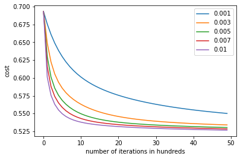

```python
# candidate learning rates
learning_rates = [0.001,0.003,0.005,0.007,0.01]
models = []

for i in learning_rates:
    d = model(X_train, y_train, X_test, y_test, 0.5, i, num_iterations=5000, print_cost=False)
    models.append(d)
for i in range(len(learning_rates)):
    plt.plot(np.squeeze(models[i]['costs']),label=str(models[i]['learning_rate']))
plt.ylabel('cost')
plt.xlabel('number of iterations in hundreds')
plt.legend()
plt.show()
```

Notice that we get the best accuracy results for learning rate 0.005. We see that it is among the faster convergent learning rates. Note that merely looking at the cost is not enough because if we choose the cost too low, there is a danger of overfitting. And with a very small learning rate we see that the cost is higher, convergence is not as fast and we are in danger of having a model that is too general and has high variance.

In the next subsection, we will check the difference between the train and test accuracies - we will see that the model is overfitting if the train accuracy is higher than the test accuracy. This will justify and guide our choice of the optimal parameters.

##### 2.1.2.

We now compare the performance of the optimal model on the training data and on the test data by their mean accuracies.

```python
# optimal hyperparameters
learning_rate_opt = learn_rate[max_acc1[0],max_acc1[1]]
decision_threshold_opt = dec_thr[max_acc1[0],max_acc1[1]]
print('\nOptimal:\nLearning rate:',learning_rate_opt,'\nDecision threshold:',decision_threshold_opt)
d = model(X_train, y_train, X_test, y_test, decision_threshold_opt, learning_rate_opt, num_iterations=5000, print_acc=True)

# vary learning_rate
learning_rate = 0.001
decision_threshold = decision_threshold_opt
print('\nVarying learning rate:\nLearning rate:',learning_rate,'\nDecision threshold:',decision_threshold)
d = model(X_train, y_train, X_test, y_test, decision_threshold, learning_rate, num_iterations=5000, print_acc=True)
learning_rate = 0.05
decision_threshold = decision_threshold_opt
print('\nLearning rate:',learning_rate,'\nDecision threshold:',decision_threshold)
d = model(X_train, y_train, X_test, y_test, decision_threshold, learning_rate, num_iterations=5000, print_acc=True)

# vary decision_threshold
learning_rate = learning_rate_opt
decision_threshold = 0.3
print('\nVarying decision threshold:\nLearning rate:',learning_rate,'\nDecision threshold:',decision_threshold)
d = model(X_train, y_train, X_test, y_test, decision_threshold, learning_rate, num_iterations=5000, print_acc=True)
learning_rate = learning_rate_opt
decision_threshold = 0.5
print('\nLearning rate:',learning_rate,'\nDecision threshold:',decision_threshold)
d = model(X_train, y_train, X_test, y_test, decision_threshold, learning_rate, num_iterations=5000, print_acc=True)
```

```
Optimal:
Learning rate: 0.005
Decision threshold: 0.4
train accuracy: 74.125 %
test accuracy: 76.0 %

Varying learning rate:
Learning rate: 0.001
Decision threshold: 0.4
train accuracy: 72.0 %
test accuracy: 74.5 %

Learning rate: 0.05
Decision threshold: 0.4
train accuracy: 73.375 %
test accuracy: 75.5 %

Varying decision threshold:
Learning rate: 0.005
Decision threshold: 0.3
train accuracy: 73.5 %
test accuracy: 74.5 %

Learning rate: 0.005
Decision threshold: 0.5
train accuracy: 74.625 %
test accuracy: 67.0 %
```

For the optimal parameters we found using the grid search, the difference between the train accuracy and test accuracy (averaged over the 5 folds) is quite small, the test accuracy is bigger which means our model is not overfitted. It is not performing very well, thus suggesting that it may have larger variance than we would want.

Varying the parameters a bit and comparing the accuracies we get, we see that the model is more sensitive to changes in decision threshold rather than learning rate.

#### 2.2. Random Forests

##### 2.2.1.

```python
# get the data ready
header = ['col'+str(i) for i in range(12)]
data_train = pd.read_csv("classification_train.csv", names=header)
data_train.head(2)
```

|  | col0 | col1 | col2 | col3 | col4 | col5 | col6 | col7 | col8 | col9 | col10 | col11 |
| --- | --- | --- | --- | --- | --- | --- | --- | --- | --- | --- | --- | --- |
| 0 | 0.161765 | 0.25 | 0.363156 | 0.25 | 0.0 | 0.000000 | 0.333333 | 0.333333 | 0.267857 | 1.0 | 1.0 | 0.0 |
| 1 | 0.470588 | 0.50 | 0.858754 | 0.00 | 0.0 | 0.333333 | 0.666667 | 0.666667 | 0.428571 | 1.0 | 0.0 | 1.0 |

```python
# Test data
data_test = pd.read_csv("classification_test.csv", names=header)
data_test.head(2)
```

|  | col0 | col1 | col2 | col3 | col4 | col5 | col6 | col7 | col8 | col9 | col10 | col11 |
| --- | --- | --- | --- | --- | --- | --- | --- | --- | --- | --- | --- | --- |
| 0 | 0.205882 | 0.5 | 0.069055 | 0.0 | 0.5 | 1.000000 | 0.333333 | 1.0 | 0.232143 | 1.000000 | 1.0 | 1.0 |
| 1 | 0.382353 | 0.0 | 0.238418 | 0.0 | 0.5 | 0.333333 | 0.333333 | 0.0 | 0.232143 | 0.666667 | 0.0 | 1.0 |

```python
# training set into matrix
arr_train = data_train.to_numpy()
print('full dataset size',arr_train.shape)
# eliminate the sixth column in train set
arr_train = np.delete(arr_train, 6, 1)

# shuffle it with the same seed
random.seed(1007)
random.shuffle(arr_train) # this is a numpy array

# split it
X_train = arr_train[:,:-1]
y_train = arr_train[:,-1]



print('shape of matrix X containing training predictors',X_train.shape)
print('length of y_train',len(y_train))

# test set into matrix
arr_test = data_test.to_numpy()
# eliminate the sixth column in train set and test set
arr_test = np.delete(arr_test, 6, 1)
# shuffle it with same seed
random.seed(1007)
random.shuffle(arr_test)
# split it
X_test = arr_test[:,:-1]
y_test = arr_test[:,-1]


print('\nshapes of X_train and X_test:',X_train.shape,X_test.shape)
```

```
full dataset size (800, 12)
shape of matrix X containing training predictors (800, 10)
length of y_train 800

shapes of X_train and X_test: (800, 10) (200, 10)
```

```python
# standardize the X_train and X_test
def standardise(X):
    mu = np.mean(X, 0)
    sigma = np.std(X, 0)
    X_std = (X - mu) / sigma
    return X_std
```

```python
X_train = standardise(X_train)
X_test = standardise(X_test)
```

```python
# define cross-entropy loss function to account for information gain
def entropy(y, sample_weights=None):
  if sample_weights is None:
      sample_weights = np.ones(y.shape[0]) / y.shape[0]

  entropy = 0
  num = y.shape[0]  # number of labels
  label_counts = {}  # calculate different labels in y，and store in label_counts
  for i in range(num):
      if y[i] not in label_counts.keys():
          label_counts[y[i]] = 0
      label_counts[y[i]] += sample_weights[i]

  for key in label_counts:
      prob = float(label_counts[key]) / float(np.sum(sample_weights))
      entropy -= prob*math.log2(prob)

  return entropy
```

```python
# check if we get a reasonable value for the entropy
e = entropy(y_train)
print(e)
```

```
0.8687212463394132
```

We have prepared the data and defined entropy, now define the functions for the random forest implementation.

```python
def split_dataset(X, y, column, value, sample_weights=None):
  ret = []
  featVec = X[:, column]
  X = X[:,[i for i in range(X.shape[1]) if i!=column]]

  for i in range(len(featVec)):
      if featVec[i]==value:
          ret.append(i)

  sub_X = X[ret,:]
  sub_y = y[ret]
  sub_sample_weights = sample_weights[ret]

  return sub_X, sub_y, sub_sample_weights
```

```python
def entropy_purification(X, y, column, sample_weights=None):
  if sample_weights is None:
      sample_weights = np.ones(y.shape[0]) / y.shape[0]

  new_entropy = 0
  old_cost = entropy(y, sample_weights)

  unique_vals = np.unique(X[:, column])

  new_cost = 0.0
  #split the values of i-th feature and calculate the cost
  for value in unique_vals:
      sub_X, sub_y, sub_sample_weights = split_dataset(X, y, column, value, sample_weights)
      prob = np.sum(sub_sample_weights) / float(np.sum(sample_weights))
      new_cost += prob * entropy(sub_y, sub_sample_weights)

  new_entropy = old_cost - new_cost # information gain

  return new_entropy
```

```python
# evaluate for feature 2
entropy_purification(X_train, y_train, 2)
```

```
0.8452776369617089
```

Function that determines the best feature to split by:

```python
def choose_best_feature(X, y,n_features, sample_weights=None):
  if sample_weights is None:
      sample_weights = np.ones(y.shape[0]) / y.shape[0]

  best_feature_idx = 0
#   n_features = X.shape[1]

  # use C4.5 algorirhm
  best_gain_cost = 0.0
  for i in range(n_features):
      info_gain_cost = entropy_purification(X, y, i, sample_weights)
      if info_gain_cost > best_gain_cost:
          best_gain_cost = info_gain_cost
          best_feature_idx = i

  return best_feature_idx
```

```python
n_features = 3
choose_best_feature(X_train, y_train,n_features)
```

```
2
```

Analyse the predictor columns to notice why for any number of features larger than 2 we get the best feature as column 2:

```python
for i in range(X_train.shape[1]):
    print('Number of unique values in column',i,'is',len(np.unique(X_train[:, i])))
```

```
Number of unique values in column 0 is 30
Number of unique values in column 1 is 5
Number of unique values in column 2 is 387
Number of unique values in column 3 is 5
Number of unique values in column 4 is 5
Number of unique values in column 5 is 4
Number of unique values in column 6 is 4
Number of unique values in column 7 is 49
Number of unique values in column 8 is 4
Number of unique values in column 9 is 2
```

Notice that in column 2 we have an unreasonably large number of unique values. The algorithm chooses the descriptoor with the most features as it gives the most information - the cross entropy is expected to have the largest value for column 2. As we choose column 2, very time there is an unique value, we get a new subtree and do not use the full possible depth. This will make the random forest memorise our data and overfit.

Check the cross entropy values:

```
Column 0 cross entropy is 0.11388863275776762
Column 1 cross entropy is 0.03381845069121381
Column 2 cross entropy is 0.8452776369617089
Column 3 cross entropy is 0.022995566261031164
Column 4 cross entropy is 0.01085462186586672
Column 5 cross entropy is 0.008291839223173891
Column 6 cross entropy is 0.037931868102222155
Column 7 cross entropy is 0.16044101435451585
Column 8 cross entropy is 0.021206763801311035
Column 9 cross entropy is 0.0012997664656910768
```

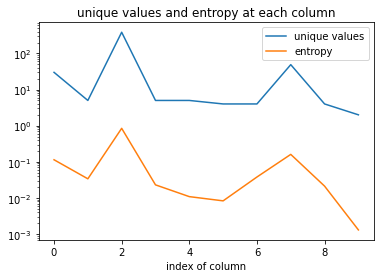

```python
unique = []
entr = []
for i in range(X_train.shape[1]):
    u = len(np.unique(X_train[:, i]))
    unique.append(u)
    e = entropy_purification(X_train, y_train, i)
    entr.append(e)
    print('Column',i,'cross entropy is', e)


plt.plot(unique,label='unique values')
plt.plot(entr,label='entropy')
plt.yscale('log')
plt.xlabel('index of column')
plt.title('unique values and entropy at each column')
plt.legend()
plt.show()
```

We clearly see that the entropy which guides the choice in determining the best feature to split by is dependent on the unique values in the column. A way around this is to remove columns 2, 0 and 7 later to see whether we get better results for the random forest.

Majority vote function that gives us the classification label (in out case 0 or 1) that is most common in y:

```python
def majority_vote(y, sample_weights=None):
  if sample_weights is None:
      sample_weights = np.ones(y.shape[0]) / y.shape[0]

  majority_label = y[0]

  dict_num = {}
  for i in range(y.shape[0]):
      if y[i] not in dict_num.keys():
          dict_num[y[i]] = sample_weights[i]
      else:
          dict_num[y[i]] += sample_weights[i]

  majority_label = max(dict_num, key=dict_num.get)

  return majority_label
```

```python
majority_vote(y_train)
```

```
1.0
```

Define the decision tree building and training functions:

```python
def build_tree(X, y, n_features, feature_names, depth, sample_weights=None, max_depth=10, min_samples_leaf=2):
    mytree = dict()
    # include a clause for the cases where (i) no feature, (ii) all labels are the same, (iii) depth exceed, or (iv) X is too small
    if len(feature_names)==0 or len(np.unique(y))==1 or depth>=max_depth or len(X)<=min_samples_leaf:
        return majority_vote(y, sample_weights)

    else:
        best_feature_idx = choose_best_feature(X, y, n_features, sample_weights)
        best_feature_name = feature_names[best_feature_idx]
        feature_names = feature_names[:]
        feature_names.remove(best_feature_name)

    mytree = {best_feature_name:{}}

    unique_vals = np.unique(X[:, best_feature_idx])

    for value in unique_vals:
        sub_X, sub_y, sub_sample_weights = split_dataset(X, y, best_feature_idx, value, sample_weights)
        mytree[best_feature_name][value] = build_tree(sub_X, sub_y, n_features, feature_names, depth+1, sub_sample_weights)

    return mytree
```

```python
def train(X, y, n_features, depth, sample_weights=None):
  """
  Build the decision tree according to the training data.
  Args:
      X: (pd.Dataframe) training features, of shape (N, D). Each X[i] is a training sample.
      y: (pd.Series) vector of training labels, of shape (N,). y[i] is the label for X[i], and each y[i] is
      an integer in the range 0 <= y[i] <= C. Here C = 1.
      sample_weights: weights for each samples, of shape (N,).
  """
  if sample_weights is None:
      # if the sample weights is not provided, we assume the samples have uniform weights
      sample_weights = np.ones(X.shape[0]) / X.shape[0]
  else:
      sample_weights = np.array(sample_weights) / np.sum(sample_weights)

  feature_names = X.columns.tolist()
  X = np.array(X)
  y = np.array(y)
  tree = build_tree(X, y,n_features, feature_names, depth, sample_weights=sample_weights)
  return tree
```

Check the train function outputs a tree as expected

```python
# stack the standardised training data together and turn into dataframe
y_train = (np.zeros((1,800))+y_train).T
data_train = np.hstack((X_train,y_train))
data_train = pd.DataFrame(data_train)

# dataframes
X_1 = data_train.iloc[:,:-1]
y_1 = data_train.iloc[:,-1]

# set default hyperparameters
depth = 5
n_features = 5

# fit the decision tree with training data
tree3 = train(X_1, y_1, n_features, depth)
# print(tree3)
```

```python
# stack the standardised testing data together and turn into dataframe
y_test = (np.zeros((1,200))+y_test).T
data_test = np.hstack((X_test,y_test))
data_test = pd.DataFrame(data_test)

# dataframes
X_2 = data_test.iloc[:,:-1]
y_2 = data_test.iloc[:,-1]
```

```python
def classify(tree, x):  # classify one element of y_pred with the fitted decision tree
  feature_name = list(tree.keys())[0]  # select first element of the tree dict - the feature name
  second_dict = tree[feature_name]
  key = x.loc[feature_name]
  if key not in second_dict:
      key = np.random.choice(list(second_dict.keys()))
  value_of_key = second_dict[key]
  if isinstance(value_of_key, dict):
      label = classify(value_of_key, x)
  else:
      label=value_of_key
  return label
```

Finally, this function outputs a numpy array of the classification prediction using the above classification function that classifies each 'row' (element of y_pred) using the decision tree we trained.

```python
def predict(X, y, tree):
    if len(X.shape)==1:
        return classify(tree, X)
    else:
        results=[]
        for i in range(X.shape[0]):
            results.append(classify(tree, X.iloc[i, :]))
        return np.array(results)
```

```python
def score(X_test, y_test, tree, depth):
    y_pred = predict(X_test, y_test, tree)  # X_test and y_test are pandas dataframes
    return np.float(sum(y_pred==y_test)) / float(len(y_test)), y_pred
```

```python
tr_acc, tr_y_pred = score(X_1, y_1, tree3, depth)
test_acc, test_y_pred = score(X_2, y_2, tree3, depth)
print('Training accuracy:', tr_acc)
print('Test accuracy:', test_acc)
```

```
Training accuracy: 0.9975
Test accuracy: 0.54
```

The model with default hyperparameters depth = 5, n_features = 5 has clearly overfitted the data because the training accuracy is very high and the test accuracy is much lower (nearly half of the train one). This may be due to the large number of unique values in the predictors.

Now we look for the optimal parameters:

1) number of decision trees: used in the random forest implementation

2) depth of trees: used in build_tree()

3) max number of descriptors (features) randomly chosen at each split: used in choose_best_feature()

Now that we have defined the functions to get a decision tree, we will perform a 5-fold cross validation to find the optimal parameters: we will run 5 models on different folds and judge the performance by the accuracy of the predictions.

```python
def score2(y_pred, y_test):
    return np.float(sum(y_pred==y_test)) / float(len(y_test)), y_pred  # accuracy of predictions

# data and data_test are np.arrays
def cross_val_evaluate_RF(data, data_test, num_folds, n_features, n_trees=5, depth=1,print_accs=True):

    folds = cross_val_split(data, num_folds) # split data into folds

    # convert and split the test data into X_test and y_tests
    data_test = pd.DataFrame(data_test)
    X_test = data_test.iloc[:,:-1]
    y_test = data_test.iloc[:,-1]

    # initialise lists to contain the accuracies
    train_accs = []
    val_accs = []
    test_accs = []

    VAL_ACC = []
    TEST_ACC = []

    # initialise the list to contain the prediction for the five folds
    y_preds_val_fold = []
    y_preds_test_fold = []

    if print_accs:
        print('\n\ndepth',depth)
        print('nb of trees',n_trees)
        print('nb of features',n_features)

    for i in range(len(folds)):
        if print_accs:
            print('\nfold',i+1)
        # define the training set
        train_set = np.delete(np.asarray(folds).reshape(len(folds), folds[0].shape[0], folds[0].shape[1]), i, axis=0)
        train_folds = train_set.reshape(len(train_set)*train_set[0].shape[0], train_set[0].shape[1])

        # define the validation set
        val_fold = folds[i]

        # convert to dataframes
        train_folds = pd.DataFrame(train_folds) # train
        val_fold = pd.DataFrame(val_fold) # validation

        # get the lists for average accuracies for the forests
        avg_train_accs = []
        avg_val_accs = []
        avg_test_accs = []

        y_trains_forest = []
        y_val_forest = []
        y_test_forest = []


        # loop through the forest
        for n in range(n_trees):
            sample_tr = train_folds.sample(n=train_folds.shape[0], replace=True, random_state=n)  # change the random state to have different sampling for each tree
            X_tr1 = sample_tr.iloc[:,:-1]
            y_tr1 = sample_tr.iloc[:,-1]

#             sample_val = val_fold.sample(n=val_fold.shape[0], replace=True, random_state=1)
            X_tr2 = val_fold.iloc[:,:-1]
            y_tr2 = val_fold.iloc[:,-1]

            # create the tree with this set of parameters and sampled training set
            tree = train(X_tr1, y_tr1, n_features, depth)

            # get the accuracy and prediction for each individual tree
            train_acc, tr_y_pred = score(X_tr1, y_tr1, tree, depth)  # we need to input the training set, the testing set and the hyperparameters
            avg_train_accs.append(train_acc)

            val_acc, val_y_pred = score(X_tr2, y_tr2, tree, depth)
            avg_val_accs.append(val_acc)

            test_acc, test_y_pred = score(X_test, y_test, tree, depth)
            avg_test_accs.append(test_acc)

            # append the y_preds
            y_trains_forest.append(tr_y_pred)
            y_val_forest.append(val_y_pred)
            y_test_forest.append(test_y_pred)


        # append the average of the validation and test accuracies over the individual trees
        VAL_ACC.append(np.average(avg_val_accs))
        TEST_ACC.append(np.average(avg_test_accs))

        # sum the predictions of the trees over the forest
        y_tr_sum_forest = [sum(i) for i in zip(*y_trains_forest)]
        y_val_sum_forest = [sum(i) for i in zip(*y_val_forest)]
        y_test_sum_forest = [sum(i) for i in zip(*y_test_forest)]

        # divide by the number of trees
        y_tr_sum_forest = [i/n_trees for i in y_tr_sum_forest]
        y_val_sum_forest = [i/n_trees for i in y_val_sum_forest]
        y_test_sum_forest = [i/n_trees for i in y_test_sum_forest]

        # set to 1 if above 0.5 set to 0 if below 0.5, set the case for 0.5 to equal 0 to avoid false positives
        for k in range(len(y_tr_sum_forest)):
            if y_tr_sum_forest[k]>0.5:
                y_tr_sum_forest[k]=1
            else:
                y_tr_sum_forest[k]=0

        for k in range(len(y_val_sum_forest)):  # this is our y_pred over the validation fold
            if y_val_sum_forest[k]>0.5:
                y_val_sum_forest[k]=1
            else:
                y_val_sum_forest[k]=0

        for k in range(len(y_test_sum_forest)):  # this is our y_pred over the validation fold
            if y_test_sum_forest[k]>0.5:
                y_test_sum_forest[k]=1
            else:
                y_test_sum_forest[k]=0

        # we now have the prediction for this forest, calculate the score for this fold:
        score12,_ = score2(y_tr_sum_forest, y_tr1)
        score1,_ = score2(y_val_sum_forest, y_tr2)
        score_test,_ = score2(y_test_sum_forest, y_test)
        if print_accs:
            print('accuracy, training set, fold',i+1,'is',score12)
            print('accuracy, validation set, fold',i+1,'is',score1)
            print('accuracy, test set, fold',i+1,'is',score_test)

        # append the scores for each fold
        train_accs.append(score12)
        val_accs.append(score1)
        test_accs.append(score_test)


        # append the y_pred validation for each fold
        y_preds_val_fold.append(y_val_sum_forest)
        y_preds_test_fold.append(y_test_sum_forest)

    return train_accs, val_accs, test_accs, y_preds_val_fold, y_preds_test_fold, VAL_ACC, TEST_ACC
```

```python
# we have pandas dataframes data_train, data_train with standardised descriptors, turn them into numpy arrays
arr_train1 = data_train.to_numpy()
arr_test1 = data_test.to_numpy()
```

Run the cross-validation function to check whether we have reasonable accuracies.

```python
n_features = 5
n_trees = 5
depth = 5

train_accs,val_accs,test_accs,_,y_test_pred, VAL_ACC, TEST_ACC  = cross_val_evaluate_RF(arr_train1,arr_test1, 5, n_features, n_trees, depth)
print(VAL_ACC)
print(TEST_ACC)
print(y_test_pred)
```

```
depth 5
nb of trees 5
nb of features 5

fold 1
accuracy, training set, fold 1 is 0.734375
accuracy, validation set, fold 1 is 0.9
accuracy, test set, fold 1 is 0.695

fold 2
accuracy, training set, fold 2 is 0.75
accuracy, validation set, fold 2 is 0.84375
accuracy, test set, fold 2 is 0.67

fold 3
accuracy, training set, fold 3 is 0.7375
accuracy, validation set, fold 3 is 0.85625
accuracy, test set, fold 3 is 0.675

fold 4
accuracy, training set, fold 4 is 0.740625
accuracy, validation set, fold 4 is 0.91875
accuracy, test set, fold 4 is 0.685

fold 5
accuracy, training set, fold 5 is 0.7421875
accuracy, validation set, fold 5 is 0.925
accuracy, test set, fold 5 is 0.65
[0.8275, 0.8, 0.8074999999999999, 0.8550000000000001, 0.8262499999999999]
[0.61, 0.576, 0.595, 0.6119999999999999, 0.604]
[[1, 1, 1, 1, 0, 0, 1, 1, 1, 1, 1, 1, 1, 1, 1, 1, 1, 1, 0, 1, 1, 1, 1, 1, 1, 1, 1, 1, 0, 1, 1, 1, 1, 0, 1, 1, 1, 1, 1, 1, 0, 1, 1, 1, 1, 1, 1, 0, 1, 1, 1, 1, 1, 1, 1, 1, 1, 1, 1, 1, 1, 1, 0, 1, 1, 1, 1, 1, 1, 1, 1, 0, 1, 1, 1, 1, 1, 1, 1, 1, 1, 1, 1, 1, 1, 1, 1, 1, 1, 1, 0, 1, 1, 1, 1, 1, 1, 1, 0, 1…
```

Having a lowest testing accuracy on unseen data seems reasonable, and printing out the predictions for y_test shows that we do not get predictions of the same class at all times.

Note that in what follows we take the metric as the validation and testing accuracy of the final y_pred averaged over the five folds. We will then compare this metric in determining the optimal hyperparameters based on the average of the accuracies over the individual trees.

The acccuracies on the training set are larger than on the test set, this is expected, so we continue by scanning through the optimal parameters separately.

i) Investigate the accuracies over different depths with other hyperparameters set to constant values.

```python
# candidate depths
depths = np.arange(1,10,2)
print('Candidate depths:',depths)

# other hyperparameters constant (adjusted after scanning for them)
n_features = 5
n_trees = 25

max_val_acc=[]
max_test_acc=[]
for d in depths:
    train_accs,val_accs,test_accs,_,_ = cross_val_evaluate_RF(arr_train1,arr_test1, 5, n_features, n_trees, depth)
    max_val_acc.append(np.average(val_accs))
    max_test_acc.append(np.average(test_accs))

print('\naverage validation accuracy:',max_val_acc)
print('average testing accuracy:',max_test_acc)
```

```
Candidate depths: [1 3 5 7 9]


depth 5
nb of trees 25
nb of features 5

fold 1
accuracy, training set, fold 1 is 0.7203125
accuracy, validation set, fold 1 is 0.93125
accuracy, test set, fold 1 is 0.725

fold 2
accuracy, training set, fold 2 is 0.715625
accuracy, validation set, fold 2 is 0.86875
accuracy, test set, fold 2 is 0.74

fold 3
accuracy, training set, fold 3 is 0.7
accuracy, validation set, fold 3 is 0.8875
accuracy, test set, fold 3 is 0.74

fold 4
accuracy, training set, fold 4 is 0.6875
accuracy, validation set, fold 4 is 0.9375
accuracy, test set, fold 4 is 0.71

fold 5
accuracy, training set, fold 5 is 0.6703125
accuracy, validation set, fold 5 is 0.90625
accuracy, test set, fold 5 is 0.73


depth 5
nb of trees 25
nb of features 5

fold 1
accuracy, training set, fold 1 is 0.7203125
accuracy, validation set, fold 1 is 0.91875
```

[output cut: 100 more lines]

```
accuracy, test set, fold 3 is 0.735

fold 4
accuracy, training set, fold 4 is 0.6875
accuracy, validation set, fold 4 is 0.925
accuracy, test set, fold 4 is 0.73

fold 5
accuracy, training set, fold 5 is 0.6703125
accuracy, validation set, fold 5 is 0.9
accuracy, test set, fold 5 is 0.735

average validation accuracy: [0.90625, 0.9012500000000001, 0.905, 0.9075, 0.9]

average testing accuracy: [0.729, 0.734, 0.732, 0.734, 0.732]
```

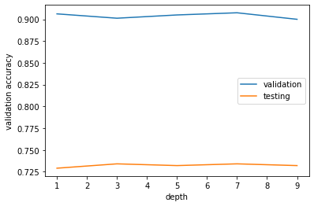

```python
plt.plot(depths,max_val_acc,label='validation')
plt.plot(depths,max_test_acc,label='testing')
plt.xlabel('depth')
plt.ylabel('validation accuracy')
plt.legend()
plt.show()
```

```python
nbs_trees = [2,5,9,12,16,20,30,40]
print(nbs_trees)
depth_opt = 3
n_features = 4

max_val_acc=[]
max_test_acc=[]
for nb in nbs_trees:
    train_accs,val_accs,test_accs,_,_ = cross_val_evaluate_RF(arr_train1,arr_test1, 5, n_features, n_trees=nb, depth=depth_opt)
    max_val_acc.append(np.average(val_accs))
    max_test_acc.append(np.average(test_accs))

print('\naverage validation accuracy:',max_val_acc)
print('\naverage testing accuracy:',max_test_acc)
```

```
[2, 5, 9, 12, 16, 20, 30, 40]


depth 3
nb of trees 2
nb of features 4

fold 1
accuracy, training set, fold 1 is 0.8125
accuracy, validation set, fold 1 is 0.83125
accuracy, test set, fold 1 is 0.455

fold 2
accuracy, training set, fold 2 is 0.828125
accuracy, validation set, fold 2 is 0.78125
accuracy, test set, fold 2 is 0.545

fold 3
accuracy, training set, fold 3 is 0.8109375
accuracy, validation set, fold 3 is 0.81875
accuracy, test set, fold 3 is 0.57

fold 4
accuracy, training set, fold 4 is 0.7859375
accuracy, validation set, fold 4 is 0.81875
accuracy, test set, fold 4 is 0.5

fold 5
accuracy, training set, fold 5 is 0.778125
accuracy, validation set, fold 5 is 0.8
accuracy, test set, fold 5 is 0.55


depth 3
nb of trees 5
nb of features 4

fold 1
accuracy, training set, fold 1 is 0.734375
accuracy, validation set, fold 1 is 0.89375
```

[output cut: 190 more lines]

```
accuracy, test set, fold 3 is 0.735

fold 4
accuracy, training set, fold 4 is 0.68125
accuracy, validation set, fold 4 is 0.9375
accuracy, test set, fold 4 is 0.735

fold 5
accuracy, training set, fold 5 is 0.671875
accuracy, validation set, fold 5 is 0.9125
accuracy, test set, fold 5 is 0.73

average validation accuracy: [0.8099999999999999, 0.8825, 0.885, 0.8712500000000001, 0.9012499999999999, 0.8987499999999999, 0.9087499999999998, 0.9075]

average testing accuracy: [0.524, 0.6809999999999999, 0.71, 0.6910000000000001, 0.702, 0.726, 0.731, 0.734]
```

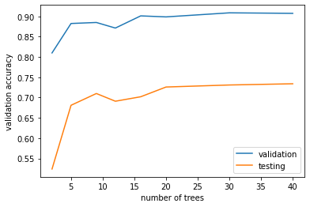

```python
plt.plot(nbs_trees,max_val_acc,label='validation')
plt.plot(nbs_trees,max_test_acc,label='testing')
plt.xlabel('number of trees')
plt.ylabel('validation accuracy')
plt.legend()
plt.show()
```

We see that the accuracy plateau is at around 25, so we take this as the optimal value; ideally it would be larger for marginally better accuracies but we have serious computational power constraints. A larger number of trees is more optimal as there is more averaging out of outtlier accuracies.

The maximum depth is one of the stopping criteria for the algorithm - it sets a maximum number of splits in the decision tree.

iii) Now investigate the optimal number of features randomly chosen at each split, note that we cannot go above 9 because there are 10 training features overall. Choose optimal n_trees = 25 and depth = 3.

```python
nbs_feat = np.arange(3,10,2)
print(nbs_feat)
n_trees_opt = 25
depth_opt = 3

max_val_acc = []
max_test_acc = []
for nb in nbs_feat:
    train_accs,val_accs,test_accs,_,_ = cross_val_evaluate_RF(arr_train1, arr_test1, 5, n_features=nb, n_trees=n_trees_opt, depth=depth_opt)
    max_val_acc.append(np.average(val_accs))
    max_test_acc.append(np.average(test_accs))

print('\naverage validation accuracy:',max_val_acc)
print('\naverage testing accuracy:',max_test_acc)
```

```
[3 5 7 9]


depth 3
nb of trees 25
nb of features 3

fold 1
accuracy, training set, fold 1 is 0.7203125
accuracy, validation set, fold 1 is 0.91875
accuracy, test set, fold 1 is 0.73

fold 2
accuracy, training set, fold 2 is 0.715625
accuracy, validation set, fold 2 is 0.86875
accuracy, test set, fold 2 is 0.725

fold 3
accuracy, training set, fold 3 is 0.7
accuracy, validation set, fold 3 is 0.89375
accuracy, test set, fold 3 is 0.735

fold 4
accuracy, training set, fold 4 is 0.6875
accuracy, validation set, fold 4 is 0.9375
accuracy, test set, fold 4 is 0.72

fold 5
accuracy, training set, fold 5 is 0.6703125
accuracy, validation set, fold 5 is 0.9125
accuracy, test set, fold 5 is 0.73


depth 3
nb of trees 25
nb of features 5

fold 1
accuracy, training set, fold 1 is 0.7203125
accuracy, validation set, fold 1 is 0.9375
```

[output cut: 70 more lines]

```
accuracy, test set, fold 3 is 0.73

fold 4
accuracy, training set, fold 4 is 0.6875
accuracy, validation set, fold 4 is 0.9375
accuracy, test set, fold 4 is 0.725

fold 5
accuracy, training set, fold 5 is 0.6703125
accuracy, validation set, fold 5 is 0.90625
accuracy, test set, fold 5 is 0.735

average validation accuracy: [0.90625, 0.9075000000000001, 0.9087500000000001, 0.90625]

average testing accuracy: [0.728, 0.726, 0.7370000000000001, 0.729]
```

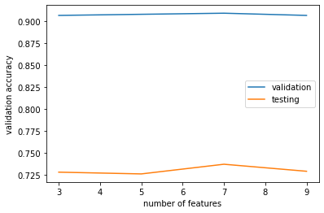

```python
plt.plot(nbs_feat,max_val_acc,label='validation')
plt.plot(nbs_feat,max_test_acc,label='testing')
plt.xlabel('number of features')
plt.ylabel('validation accuracy')
plt.legend()
plt.show()
```

There is no significant variation in the accuracies, only from the testing accuracy we clearly see that we can choose the optimal number of features as 7.

Now that we have an intuition for the optimal ranges, we loop through some candidate values (grid search) to get the best combination of hyperparameters. This time we do not save all the values, just update the optimal parameters on the fly.

```python
nbs_trees = [3,13,20,25,30]
print('candidate numbers of features',nbs_trees)
nbs_feat = np.arange(5,10,2)
print('candidate numbers of features',nbs_feat)
depths = np.arange(2,8,2)
print('candidate depths',depths)
```

```
candidate numbers of features [3, 13, 20, 25, 30]
candidate numbers of features [5 7 9]
candidate depths [2 4 6]
```

```python
max_acc_val = 0
max_acc_test = 0
list_params_val = [0,0,0]  # [tree, n_features, depths]
list_params_test = [0,0,0]
for tr in nbs_trees:
    print('\nLoading for',tr,'trees...')
    for feat in nbs_feat:
        print('Loading for',feat,'features...')
        for d in depths:
            _,val_accs,test_accs,_,_ = cross_val_evaluate_RF(arr_train1, arr_test1, 5, n_features=feat, n_trees=tr, depth=d,print_accs=False)
            acc_new_val = np.average(val_accs)
            if acc_new_val>max_acc_val:
                max_acc_val = acc_new_val
                list_params_val = [tr,feat,d]

            acc_new_test = np.average(test_accs)
            print('depth',d,'average testing accuracy',acc_new_test)
            if acc_new_test>max_acc_test:
                max_acc_test = acc_new_test
                list_params_test = [tr,feat,d]

print('max_acc_val',max_acc_val)
print(list_params_val)

print('max_acc_test',max_acc_test)
print(list_params_test)
```

```
Loading for 3 trees...
Loading for 5 features...
depth 2 average testing accuracy 0.647
depth 4 average testing accuracy 0.6319999999999999
depth 6 average testing accuracy 0.646
Loading for 7 features...
depth 2 average testing accuracy 0.6599999999999999
depth 4 average testing accuracy 0.67
depth 6 average testing accuracy 0.662
Loading for 9 features...
depth 2 average testing accuracy 0.6449999999999999
depth 4 average testing accuracy 0.6359999999999999
depth 6 average testing accuracy 0.6540000000000001

Loading for 13 trees...
Loading for 5 features...
depth 2 average testing accuracy 0.714
depth 4 average testing accuracy 0.72
depth 6 average testing accuracy 0.7190000000000001
Loading for 7 features...
depth 2 average testing accuracy 0.7219999999999999
depth 4 average testing accuracy 0.7129999999999999
depth 6 average testing accuracy 0.72
Loading for 9 features...
depth 2 average testing accuracy 0.7220000000000001
depth 4 average testing accuracy 0.717
depth 6 average testing accuracy 0.716

Loading for 20 trees...
Loading for 5 features...
depth 2 average testing accuracy 0.718
depth 4 average testing accuracy 0.728
depth 6 average testing accuracy 0.7209999999999999
Loading for 7 features...
depth 2 average testing accuracy 0.708
depth 4 average testing accuracy 0.718
depth 6 average testing accuracy 0.7289999999999999
Loading for 9 features...
depth 2 average testing accuracy 0.7140000000000001
depth 4 average testing accuracy 0.72
```

[output cut: 18 more lines]

```
depth 2 average testing accuracy 0.736
depth 4 average testing accuracy 0.7310000000000001
depth 6 average testing accuracy 0.73
Loading for 7 features...
depth 2 average testing accuracy 0.727
depth 4 average testing accuracy 0.735
depth 6 average testing accuracy 0.7270000000000001
Loading for 9 features...
depth 2 average testing accuracy 0.731
depth 4 average testing accuracy 0.733
depth 6 average testing accuracy 0.728
max_acc_val 0.9099999999999999
[30, 7, 6]
max_acc_test 0.736
[30, 5, 2]
```

```python
print('The optimal hyperparameters for the validation sets are:')
print('Number of trees',list_params_val[0])
print('Number of features',list_params_val[1])
print('Depth',list_params_val[2])
print('Accuracy on validation sets over the five folds (average in-sample):',max_acc_val)
```

```
The optimal hyperparameters for the validation sets are:
Number of trees 30
Number of features 7
Depth 6
Accuracy on validation sets over the five folds (average in-sample): 0.9099999999999999
```

```python
print('The optimal hyperparameters for the testing are:')
print('Number of trees',list_params_test[0])
print('Number of features',list_params_test[1])
print('Depth',list_params_test[2])
print('Accuracy on test set over the five folds (average out-of-sample):',max_acc_test)
```

[output not shown]

##### alternative accuracy aggregation

We now take the metric of determining the hyperparameters based on the accuracies calculated for the prediction of each individual tree, averaged out in the number of trees in the forest, which is then averaged out over the five folds. We do this both for the validation and test sets.

```python
nbs_trees = [3,13,25]
print('candidate numbers of features',nbs_trees)
nbs_feat = np.arange(5,10,2)
print('candidate numbers of features',nbs_feat)
depths = np.arange(2,8,2)
print('candidate depths',depths)
```

```
candidate numbers of features [3, 13, 25]
candidate numbers of features [5 7 9]
candidate depths [2 4 6]
```

```python
max_acc_val = 0
max_acc_test = 0
list_params_val = [0,0,0]  # [tree, n_features, depths]
list_params_test = [0,0,0]
for tr in nbs_trees:
    print('\nLoading for',tr,'trees...')
    for feat in nbs_feat:
        print('Loading for',feat,'features...')
        for d in depths:
            _,_,_,_,_,val_accs,test_accs = cross_val_evaluate_RF(arr_train1, arr_test1, 5, n_features=feat, n_trees=tr, depth=d, print_accs=False)
            acc_new_val = np.average(val_accs)
            if acc_new_val>max_acc_val:
                max_acc_val = acc_new_val
                list_params_val = [tr,feat,d]

            acc_new_test = np.average(test_accs)
            print('depth',d,'average testing accuracy',acc_new_test)  # print out the most important metric
            if acc_new_test>max_acc_test:
                max_acc_test = acc_new_test
                list_params_test = [tr,feat,d]
```

```
Loading for 3 trees...
Loading for 5 features...
depth 2 average testing accuracy 0.5933333333333335
depth 4 average testing accuracy 0.6033333333333333
depth 6 average testing accuracy 0.6026666666666667
Loading for 7 features...
depth 2 average testing accuracy 0.607
depth 4 average testing accuracy 0.6166666666666667
depth 6 average testing accuracy 0.6053333333333334
Loading for 9 features...
depth 2 average testing accuracy 0.6026666666666667
depth 4 average testing accuracy 0.6063333333333333
depth 6 average testing accuracy 0.6106666666666667

Loading for 13 trees...
Loading for 5 features...
depth 2 average testing accuracy 0.605
depth 4 average testing accuracy 0.5963076923076923
depth 6 average testing accuracy 0.6040769230769231
Loading for 7 features...
depth 2 average testing accuracy 0.5951538461538461
depth 4 average testing accuracy 0.599076923076923
depth 6 average testing accuracy 0.6116153846153847
Loading for 9 features...
depth 2 average testing accuracy 0.599923076923077
depth 4 average testing accuracy 0.5983846153846153
depth 6 average testing accuracy 0.6003846153846154

Loading for 25 trees...
Loading for 5 features...
depth 2 average testing accuracy 0.6022000000000001
depth 4 average testing accuracy 0.60256
depth 6 average testing accuracy 0.59772
Loading for 7 features...
depth 2 average testing accuracy 0.6049999999999999
depth 4 average testing accuracy 0.60252
depth 6 average testing accuracy 0.60084
Loading for 9 features...
depth 2 average testing accuracy 0.60104
depth 4 average testing accuracy 0.6052000000000001
depth 6 average testing accuracy 0.60068
```

```python
print('Validation set:',max_acc_val)
print('optimal parameters: [trees, n_features, depth]:',list_params_val)

print('Test set:',max_acc_test)
print('optimal parameters: [trees, n_features, depth]:',list_params_test)
```

```
Validation set: 0.8375
optimal parameters: [trees, n_features, depth]: [3, 9, 2]
Test set: 0.6166666666666667
optimal parameters: [trees, n_features, depth]: [3, 7, 4]
```

This method of calculating the accuracies is not the best as it gives the optimal number of trees as the smallest one, while it is expected that the accuracy goes up as the number of trees increases.

Recall that the most important metric is the testing accuracy, but it is also important to see the accuracies on the training set to have a reasonable qualitative intuition about overfitting the training data, balancing out the generalisation to the testing data.

We therefore take the optimal hyperparameters based on the accuracies calculated using the first method, and those computed on the testing set: 30 trees, 5 features and depth 2.

Now remove columns 0 and 2 where we have a lot of unique values which makes the tree always to predict based on that value. The small optimal depth also makes sense as trees never really goes into depth after we have a number of features larger than 3. Then we will perform the grid search for that and compare the accuracy we get in the next subsection.

```python
# remove the columns
print(arr_train1[1,:8])
arr_train2 = arr_train1.copy()
arr_train2 = np.delete(arr_train2,[0,2],1)
print(arr_train2[1,:8])
print(arr_train2.shape)
```

```
[ 1.10051477 -0.46062483  4.24450299 -0.70944248 -2.01528369 -0.91297701
  0.66004637  0.66426959]
[-0.46062483 -0.70944248 -2.01528369 -0.91297701  0.66004637  0.66426959
  1.69196261 -0.85972695]
(800, 9)
```

We need to be mindful that we cannot have more than 4 features to do the cross-validation

```python
nbs_feat = [1,2]

max_acc_val = 0
max_acc_test = 0
list_params_val = [0,0,0]  # [tree, n_features, depths]
list_params_test = [0,0,0]
for tr in nbs_trees:
    print('\nLoading for',tr,'trees...')
    for feat in nbs_feat:
        print('Loading for',feat,'features...')
        for d in depths:
            _,val_accs,test_accs,_,_ = cross_val_evaluate_RF(arr_train2, arr_test1, 5, n_features=feat, n_trees=tr, depth=d,print_accs=False)
            acc_new_val = np.average(val_accs)
            if acc_new_val>max_acc_val:
                max_acc_val = acc_new_val
                list_params_val = [tr,feat,d]

            acc_new_test = np.average(test_accs)
            print('depth',d,'average testing accuracy',acc_new_test)
            if acc_new_test>max_acc_test:
                max_acc_test = acc_new_test
                list_params_test = [tr,feat,d]

print('max_acc_val',max_acc_val)
print(list_params_val)

print('max_acc_test',max_acc_test)
print(list_params_test)
```

```
Loading for 3 trees...
Loading for 1 features...
depth 2 average testing accuracy 0.567
depth 4 average testing accuracy 0.592
depth 6 average testing accuracy 0.6210000000000001
Loading for 2 features...
depth 2 average testing accuracy 0.579
depth 4 average testing accuracy 0.621
depth 6 average testing accuracy 0.587

Loading for 13 trees...
Loading for 1 features...
depth 2 average testing accuracy 0.677
depth 4 average testing accuracy 0.6839999999999999
depth 6 average testing accuracy 0.6890000000000001
Loading for 2 features...
depth 2 average testing accuracy 0.672
depth 4 average testing accuracy 0.666
depth 6 average testing accuracy 0.667

Loading for 20 trees...
Loading for 1 features...
depth 2 average testing accuracy 0.6759999999999999
depth 4 average testing accuracy 0.689
depth 6 average testing accuracy 0.6950000000000001
Loading for 2 features...
depth 2 average testing accuracy 0.683
depth 4 average testing accuracy 0.6719999999999999
depth 6 average testing accuracy 0.6579999999999999

Loading for 25 trees...
Loading for 1 features...
depth 2 average testing accuracy 0.716
depth 4 average testing accuracy 0.7060000000000001
depth 6 average testing accuracy 0.718
Loading for 2 features...
depth 2 average testing accuracy 0.704
depth 4 average testing accuracy 0.712
depth 6 average testing accuracy 0.693

Loading for 30 trees...
Loading for 1 features...
depth 2 average testing accuracy 0.6950000000000001
depth 4 average testing accuracy 0.707
depth 6 average testing accuracy 0.7139999999999999
Loading for 2 features...
depth 2 average testing accuracy 0.707
depth 4 average testing accuracy 0.6910000000000001
depth 6 average testing accuracy 0.6859999999999999
max_acc_val 0.9000000000000001
[30, 2, 2]
max_acc_test 0.718
[25, 1, 6]
```

Print out the optimal hyperparameters based on the accuracies over the validation and test sets:

```python
print('The optimal hyperparameters for the validation sets are:')
print('Number of trees',list_params_val[0])
print('Number of features',list_params_val[1])
print('Depth',list_params_val[2])
print('Accuracy on validation sets over the five folds (average in-sample):',max_acc_val)

print('The optimal hyperparameters for the testing are:')
print('Number of trees',list_params_test[0])
print('Number of features',list_params_test[1])
print('Depth',list_params_test[2])
print('Accuracy on test set over the five folds (average out-of-sample):',max_acc_test)
```

```
The optimal hyperparameters for the validation sets are:
Number of trees 30
Number of features 2
Depth 2
Accuracy on validation sets over the five folds (average in-sample): 0.9000000000000001
The optimal hyperparameters for the testing are:
Number of trees 25
Number of features 1
Depth 6
Accuracy on test set over the five folds (average out-of-sample): 0.718
```

##### alternative accuracy aggregation

```python
nbs_feat = [1,2]

max_acc_val = 0
max_acc_test = 0
list_params_val = [0,0,0]  # [tree, n_features, depths]
list_params_test = [0,0,0]
for tr in nbs_trees:
    print('\nLoading for',tr,'trees...')
    for feat in nbs_feat:
        print('Loading for',feat,'features...')
        for d in depths:
            _,_,_,_,_,val_accs,test_accs = cross_val_evaluate_RF(arr_train2, arr_test1, 5, n_features=feat, n_trees=tr, depth=d,print_accs=False)
            acc_new_val = np.average(val_accs)
            if acc_new_val>max_acc_val:
                max_acc_val = acc_new_val
                list_params_val = [tr,feat,d]

            acc_new_test = np.average(test_accs)
            print('depth',d,'average testing accuracy',acc_new_test)
            if acc_new_test>max_acc_test:
                max_acc_test = acc_new_test
                list_params_test = [tr,feat,d]
```

```
Loading for 3 trees...
Loading for 1 features...
depth 2 average testing accuracy 0.5883333333333332
depth 4 average testing accuracy 0.5656666666666667
depth 6 average testing accuracy 0.5613333333333334
Loading for 2 features...
depth 2 average testing accuracy 0.5543333333333333
depth 4 average testing accuracy 0.5666666666666667
depth 6 average testing accuracy 0.5743333333333334

Loading for 13 trees...
Loading for 1 features...
depth 2 average testing accuracy 0.5697692307692308
depth 4 average testing accuracy 0.5783846153846154
depth 6 average testing accuracy 0.5806153846153845
Loading for 2 features...
depth 2 average testing accuracy 0.5693076923076923
depth 4 average testing accuracy 0.5664615384615385
depth 6 average testing accuracy 0.5739230769230769

Loading for 25 trees...
Loading for 1 features...
depth 2 average testing accuracy 0.5730000000000001
depth 4 average testing accuracy 0.5763199999999999
depth 6 average testing accuracy 0.58284
Loading for 2 features...
depth 2 average testing accuracy 0.56284
depth 4 average testing accuracy 0.5767599999999999
depth 6 average testing accuracy 0.56896
```

```python
print('Validation set:',max_acc_val)
print('optimal parameters: [trees, n_features, depth]:',list_params_val)

print('Test set:',max_acc_test)
print('optimal parameters: [trees, n_features, depth]:',list_params_test)
```

```
Validation set: 0.86
optimal parameters: [trees, n_features, depth]: [3, 2, 2]
Test set: 0.5883333333333332
optimal parameters: [trees, n_features, depth]: [3, 1, 2]
```

Here again we see that the optimal parameters are not what we would expect them to be, especially the number of trees, and removing the columns with the unique predictors dod not really increase the accuracy. Therefore, we will go with the optimal parameters determined using the former accuracy metric.

##### 2.2.2.

We have number of trees 30, number of features 5, depth 2, with our grid search for the full training set. On the reduced one, we get number of trees 25, number of features 1, depth 6.

Investigate the errors in both cases. We first define the confusion matrix from scratch (it was suggested on Piazza that we need to show how to implement that).

```python
def confusion_matrix(y_actual,y_pred,print_info=True):
    assert(len(y_actual)==len(y_pred))
    tp = 0
    fp = 0
    tn = 0
    fn = 0
    n = len(y_actual)
    for i in range(n):
        if y_actual[i]==1 and y_pred[i]==1: tp += 1
        if y_actual[i]==0 and y_pred[i]==1: fp += 1
        if y_actual[i]==0 and y_pred[i]==0: tn += 1
        if y_actual[i]==1 and y_pred[i]==0: fn += 1
    if print_info:
        print('TP:',tp,'FP:', fp,'TN:', tn,'FN:', fn)
    return tp, fp, tn, fn
```

Investigate just one tree:

```python
n_features = 5
depth = 2
n_trees = 30
```

```python
X_train_cm = data_train.iloc[:,:-1]  # pandas dataframe
y_train_cm = data_train.iloc[:,-1]  # pandas series

tree = train(X_train_cm, y_train_cm, n_features, depth)

y_pred = predict(X_train_cm, y_train_cm, tree)

y_actual = y_train_cm.to_numpy()

data = {'y_Actual': y_actual,
        'y_Pred': y_pred} # create a dict to input data in pd.corsstab

df_train = pd.DataFrame(data, columns=['y_Actual','y_Pred'])
confusion_matrix_train = pd.crosstab(df_train['y_Actual'], df_train['y_Pred'], rownames=['Actual'], colnames=['Predicted'])
print (confusion_matrix_train)
```

```
Predicted  0.0  1.0
Actual
0.0        231    1
1.0          1  567
```

For the test set:

```python
X_test_cm = data_test.iloc[:,:-1]
y_test_cm = data_test.iloc[:,-1]

y_pred = predict(X_test_cm, y_test_cm, tree)  # use the tree trained on the training set
y_actual = y_test_cm.to_numpy()

data = {'y_Actual': y_actual,
        'y_Pred': y_pred } # create a dict to input data in pd.corsstab
df_test = pd.DataFrame(data, columns=['y_Actual','y_Pred'])

confusion_matrix_test = pd.crosstab(df_test['y_Actual'], df_test['y_Pred'], rownames=['Actual'], colnames=['Predicted'])
print (confusion_matrix_test)

# import seaborn as sb
# sb.heatmap(confusion_matrix_test, annot=True) # visualise nicely
# plt.show()
```

```
Predicted  0.0  1.0
Actual
0.0          9   44
1.0         45  102
```

Define a function to train our data using an optimal random forest:

```python
# iterate through the trees in the forest:

def eval_forest(data_train, data_test, n_trees, n_features, depth):

    y_trains_forest = []
    y_val_forest = []

    for n in range(n_trees):
        sample_tr = data_train.sample(n=data_train.shape[0], replace=True, random_state=n)
        X_tr1 = sample_tr.iloc[:,:-1]
        y_tr1 = sample_tr.iloc[:,-1]
        X_tr2 = data_test.iloc[:,:-1]
        y_tr2 = data_test.iloc[:,-1]

        # create the tree with this set of parameters and sampled training set
        tree = train(X_tr1, y_tr1, n_features, depth)

        # get the accuracy and prediction for each individual tree
        tr_y_pred = predict(X_tr1, y_tr1, tree)  # we need to input the training set, the testing set and the hyperparameters
        val_y_pred = predict(X_tr2, y_tr2, tree)

        # call the predict function, append the y_preds
        y_trains_forest.append(tr_y_pred)
        y_val_forest.append(val_y_pred)

    # sum the predictions of the trees over the forest
    y_tr_sum_forest = [sum(i) for i in zip(*y_trains_forest)]
    y_val_sum_forest = [sum(i) for i in zip(*y_val_forest)]

    # divide by the number of trees
    y_tr_forest = [i/n_trees for i in y_tr_sum_forest]
    y_val_forest = [i/n_trees for i in y_val_sum_forest]

    # set to 1 if above 0.5 set to 0 if below 0.5, set the case for 0.5 to equal 0 to avoid false positives
    for k in range(len(y_tr_forest)):
        if y_tr_forest[k]>0.5:
            y_tr_forest[k]=1
        else:
            y_tr_forest[k]=0

    for k in range(len(y_val_forest)):  # this is our y_pred over the validation fold
        if y_val_forest[k]>0.5:
            y_val_forest[k]=1
        else:
            y_val_forest[k]=0

    return y_tr_forest, y_val_forest
```

Get the predictions from the random forest using optimal hyperparameters:

```python
n_features = 5
depth = 2
n_trees = 30
```

```python
y_pred_train, y_pred_test = eval_forest(data_train, data_test, n_trees, n_features, depth)
```

```python
# train set
X_train_cm = data_train.iloc[:,:-1]  # pandas dataframe
y_train_cm = data_train.iloc[:,-1]  # pandas series

y_actual = y_train_cm.to_numpy()

data = {'y_Actual': y_actual,
        'y_Pred': y_pred_train} # create a dict to input data in pd.corsstab

df_train = pd.DataFrame(data, columns=['y_Actual','y_Pred'])
confusion_matrix_train = pd.crosstab(df_train['y_Actual'], df_train['y_Pred'], rownames=['Actual'], colnames=['Predicted'])
print(confusion_matrix_train)

# get accuracy
score12,_ = score2(y_pred_train, y_actual)
print('\nAccuracy on training set is ',score12)
```

```
Predicted  0    1
Actual
0.0        3  229
1.0        6  562

Accuracy on training set is  0.70625
```

```python
# test set

X_test_cm = data_test.iloc[:,:-1]
y_test_cm = data_test.iloc[:,-1]

y_actual = y_test_cm.to_numpy()

data = {'y_Actual': y_actual,
        'y_Pred': y_pred_test } # create a dict to input data in pd.corsstab
df_test = pd.DataFrame(data, columns=['y_Actual','y_Pred'])

confusion_matrix_test = pd.crosstab(df_test['y_Actual'], df_test['y_Pred'], rownames=['Actual'], colnames=['Predicted'])
print (confusion_matrix_test)

# get accuracy
score12,_ = score2(y_pred_test, y_actual)
print('\nAccuracy on testing set is',score12)
```

```
Predicted  0    1
Actual
0.0        1   52
1.0        3  144

Accuracy on testing set is 0.725
```

From our random forest predictions both on the train and test set, we see that the random forest results in the predictions being biased towards positives, both true and false. This may be a result of overfitting the training data which itself contains a lot of positives.

From the logistic regression implementation, we got a 76% accuracy for the test set. Therefore, the random forest model is not the best choice for this dataset.

```python
n_features = 2
depth = 6
n_trees = 25
```

```python
data_train_c = data_train.copy()
data_test_c = data_test.copy()
```

```python
data_train_c = data_train_c.drop([0,2],1)
data_test_c = data_test_c.drop([0,2],1)
```

```python
# get predictions
y_pred_train, y_pred_test = eval_forest(data_train_c, data_test_c, n_trees, n_features, depth)
```

```python
# train set
X_train_cm = data_train.iloc[:,:-1]  # pandas dataframe
y_train_cm = data_train.iloc[:,-1]  # pandas series

y_actual = y_train_cm.to_numpy()

data = {'y_Actual': y_actual,
        'y_Pred': y_pred_train} # create a dict to input data in pd.corsstab

df_train = pd.DataFrame(data, columns=['y_Actual','y_Pred'])
confusion_matrix_train = pd.crosstab(df_train['y_Actual'], df_train['y_Pred'], rownames=['Actual'], colnames=['Predicted'])
print(confusion_matrix_train)


# get accuracy
score12,_ = score2(y_pred_train, y_actual)
print('\nAccuracy on training set is ',score12)
```

```
Predicted  0    1
Actual
0.0        3  229
1.0        0  568

Accuracy on training set is  0.71375
```

```python
# test set

X_test_cm = data_test.iloc[:,:-1]
y_test_cm = data_test.iloc[:,-1]

y_actual = y_test_cm.to_numpy()

data = {'y_Actual': y_actual,
        'y_Pred': y_pred_test } # create a dict to input data in pd.corsstab
df_test = pd.DataFrame(data, columns=['y_Actual','y_Pred'])

confusion_matrix_test = pd.crosstab(df_test['y_Actual'], df_test['y_Pred'], rownames=['Actual'], colnames=['Predicted'])
print (confusion_matrix_test)

# get accuracy
score12,_ = score2(y_pred_test, y_actual)
print('\nAccuracy on testing set is',score12)
```

```
Predicted   0    1
Actual
0.0         7   46
1.0        17  130

Accuracy on testing set is 0.685
```

We can see that removing the zero and second columns with many unique values did not really affect the accuracy of the traning, suggesting that perhaps the training set with the removed columns has too little descriptors and the model ends up overfitting the training data.

An alternative to the current approach would be modifying the building of the tree from the ground to change the branching pattern that arises in this case due to the high number of unique values in some of the columns.

### 2.3. SVMs

We define the hinge loss as $$ \mathcal L (\boldsymbol w) = \frac{1}{2} \| \boldsymbol w \|^2 + \frac{\lambda}{n} \sum_{i=1}^n \max \bigg( 0, 1-y_i (\boldsymbol w \cdot x_i + b) \bigg) \, . $$ where $\boldsymbol w$ is the vector of weights that defines the hyperplane, $\lambda$ is the regularisation parameter, and $b$ the intercept which is included in `X_train` as the additional last column of $1$'s.

Note about the interpretation of the margin: in the notebooks, we were given an algorithm that can work (roughly) for both types of margins, depending on the regularisation parameter $\lambda$ that is set. If we set it to a very large value, we recover the hard margin as errors are penalised harshly, while a very small $\lambda$ allows for a tight fit that may be too specific to the training data. This parameter essentially allows us to control the tradeoff between the complexity of the model (too complex and specific leads to overfitting) and minimising training errors (accuracy).

The considerations whether the data is linearly separable are crucial here - data that is non-linearly separable will not be fit well using any hard-margin approach using a large value for $\lambda$.

Also, we use the maximum function to account for the fact that we only take into account the values that satisfy the constraint, otherwise they do not contribute to the definition of the hyperplane that separates the data and is essentially the model.

#### 2.3.1.

Prepare the data

```python
# get the data ready
header = ['col'+str(i) for i in range(12)]
data_train = pd.read_csv("classification_train.csv", names=header)
# Test data
data_test = pd.read_csv("classification_test.csv", names=header)
```

```python
# training set into matrix
arr_train = data_train.to_numpy()
print('full dataset size',arr_train.shape)

arr_train = np.delete(arr_train, 6, 1) # eliminate the sixth column in train set
random.seed(1007) # shuffle it with the same seed
random.shuffle(arr_train) # this is a numpy array

# split it to standardise
X_train = arr_train[:,:-1]
X_train = standardise(X_train) # standardise
y_train = arr_train[:,-1]

print('shape of matrix X containing training predictors',X_train.shape)
print('length of y_train',len(y_train))

# test set into matrix
arr_test = data_test.to_numpy()
arr_test = np.delete(arr_test, 6, 1) # eliminate the sixth column in train set and test set

random.seed(1007) # shuffle it with same seed
random.shuffle(arr_test)

# split it
X_test = arr_test[:,:-1]
X_test = standardise(X_test) # standardise
y_test = arr_test[:,-1]

print('\nshapes of X_train and X_test:\n',X_train.shape)
print(X_test.shape)
```

```
full dataset size (800, 12)
shape of matrix X containing training predictors (800, 10)
length of y_train 800

shapes of X_train and X_test:
 (800, 10)
(200, 10)
```

```python
# stack the standardised training data together and turn into dataframe
y_train = (np.zeros((1,800))+y_train).T
data_train = np.hstack((X_train,y_train))
data_train = pd.DataFrame(data_train)

# stack the standardised testing data together and turn into dataframe
y_test = (np.zeros((1,200))+y_test).T
data_test = np.hstack((X_test,y_test))
data_test = pd.DataFrame(data_test)
```

```python
data_train.head(3)
```

|  | 0 | 1 | 2 | 3 | 4 | 5 | 6 | 7 | 8 | 9 | 10 |
| --- | --- | --- | --- | --- | --- | --- | --- | --- | --- | --- | --- |
| 0 | -0.492510 | -1.350721 | 1.186774 | -0.074595 | -2.015284 | -1.822543 | -0.307055 | -0.143899 | 1.691963 | 1.163160 | 0.0 |
| 1 | 1.100515 | -0.460625 | 4.244503 | -0.709442 | -2.015284 | -0.912977 | 0.660046 | 0.664270 | 1.691963 | -0.859727 | 1.0 |
| 2 | 1.100515 | -0.460625 | 4.244503 | -0.709442 | -2.015284 | -0.912977 | 0.660046 | 0.664270 | 1.691963 | -0.859727 | 1.0 |

```python
# convert 1/0 labels to 1/-1 train and set
diag_map = {1.0: 1.0, 0.0: -1.0}
data_train[10] = data_train[10].map(diag_map)
data_test[10] = data_test[10].map(diag_map)
```

```python
data_train.head(3)
```

|  | 0 | 1 | 2 | 3 | 4 | 5 | 6 | 7 | 8 | 9 | 10 |
| --- | --- | --- | --- | --- | --- | --- | --- | --- | --- | --- | --- |
| 0 | -0.492510 | -1.350721 | 1.186774 | -0.074595 | -2.015284 | -1.822543 | -0.307055 | -0.143899 | 1.691963 | 1.163160 | -1.0 |
| 1 | 1.100515 | -0.460625 | 4.244503 | -0.709442 | -2.015284 | -0.912977 | 0.660046 | 0.664270 | 1.691963 | -0.859727 | 1.0 |
| 2 | 1.100515 | -0.460625 | 4.244503 | -0.709442 | -2.015284 | -0.912977 | 0.660046 | 0.664270 | 1.691963 | -0.859727 | 1.0 |

```python
data_test.head(5)
```

|  | 0 | 1 | 2 | 3 | 4 | 5 | 6 | 7 | 8 | 9 | 10 |
| --- | --- | --- | --- | --- | --- | --- | --- | --- | --- | --- | --- |
| 0 | -0.459248 | -0.330891 | -0.723786 | -0.783729 | -0.194323 | 0.919853 | 1.597770 | -0.456945 | 1.479354 | 1.128152 | 1.0 |
| 1 | 0.456957 | -2.095645 | 0.198840 | -0.783729 | -0.194323 | -0.883780 | -1.351960 | -0.456945 | -0.037932 | -0.886405 | 1.0 |
| 2 | 0.456957 | -2.095645 | 0.198840 | -0.783729 | -0.194323 | -0.883780 | -1.351960 | -0.456945 | -0.037932 | -0.886405 | 1.0 |
| 3 | -0.459248 | -0.330891 | -0.723786 | -0.783729 | -0.194323 | 0.919853 | 1.597770 | -0.456945 | 1.479354 | 1.128152 | 1.0 |
| 4 | 0.227906 | -2.095645 | 0.411661 | -0.783729 | -2.187385 | -0.883780 | -0.368716 | 1.096408 | -0.037932 | 1.128152 | -1.0 |

```python
# split dataframes into X and y
X_1 = data_train.iloc[:,:-1]
y_1 = data_train.iloc[:,-1]

X_11 = X_1.copy()
y_11 = y_1.copy()

# dataframes
X_2 = data_test.iloc[:,:-1]
y_2 = data_test.iloc[:,-1]

X_22 = X_2.copy()
y_22 = y_2.copy()
```

```python
# insert 1 in every row for intercept b
X_1.insert(loc=len(X_1.columns), column='intercept', value=1)
X_2.insert(loc=len(X_2.columns), column='intercept', value=1)


X_111 = X_1.copy()
y_111 = y_1.copy()
X_222 = X_2.copy()
y_222 = y_2.copy()
```

```python
X_1.head(2)
```

|  | 0 | 1 | 2 | 3 | 4 | 5 | 6 | 7 | 8 | 9 | intercept |
| --- | --- | --- | --- | --- | --- | --- | --- | --- | --- | --- | --- |
| 0 | -0.492510 | -1.350721 | 1.186774 | -0.074595 | -2.015284 | -1.822543 | -0.307055 | -0.143899 | 1.691963 | 1.163160 | 1 |
| 1 | 1.100515 | -0.460625 | 4.244503 | -0.709442 | -2.015284 | -0.912977 | 0.660046 | 0.664270 | 1.691963 | -0.859727 | 1 |

```python
X_2.head(2)
```

|  | 0 | 1 | 2 | 3 | 4 | 5 | 6 | 7 | 8 | 9 | intercept |
| --- | --- | --- | --- | --- | --- | --- | --- | --- | --- | --- | --- |
| 0 | -0.459248 | -0.330891 | -0.723786 | -0.783729 | -0.194323 | 0.919853 | 1.59777 | -0.456945 | 1.479354 | 1.128152 | 1 |
| 1 | 0.456957 | -2.095645 | 0.198840 | -0.783729 | -0.194323 | -0.883780 | -1.35196 | -0.456945 | -0.037932 | -0.886405 | 1 |

We now write the functions to implement the standard linear hard-margin SVM.

```python
# define function to calculate hinge loss
def compute_cost(W, X, y, regul_strength=1e5):
    n = X.shape[0]
    distances = 1 - y * (np.dot(X, W))
    distances[distances < 0] = 0  # equivalent to max(0, distance)
    hinge = regul_strength * (np.sum(distances) / n)

    # calculate cost
    cost = 1 / 2 * np.dot(W, W) + hinge
    return cost
```

```python
# calculate gradient of cost
def calculate_cost_gradient(W, X_batch, y_batch, regul_strength=1e5):
    # if only one example is passed
    if type(y_batch) == np.float64:
        y_batch = np.asarray([y_batch])
        X_batch = np.asarray([X_batch])  # gives multidimensional array

    distance = 1 - (y_batch * np.dot(X_batch, W))
    dw = np.zeros(len(W))

    for ind, d in enumerate(distance):
        if max(0, d)==0:
            di = W
        else:
            di = W - (regul_strength * y_batch[ind] * X_batch[ind])
        dw += di

    dw = dw/len(y_batch)  # average
    return dw
```

```python
def sgd(X, y, max_iterations=2000, stop_criterion=0.01, learning_rate=1e-5, regul_strength=1e5, print_outcome=False):
  # write the initial conditions for the weights
  weights = np.ones(X.shape[1])
  nth = 0
  # initialise starting cost as infinity
  prev_cost = np.inf

  # stochastic gradient descent
  for iteration in range(1, max_iterations):
      # shuffle to prevent repeating update cycles
      np.random.shuffle([X, y])
      for ind, x in enumerate(X):
          ascent = calculate_cost_gradient(weights, x, y[ind], regul_strength)
          weights = weights - (learning_rate * ascent)

      # convergence check on 2^n'th iteration
      if iteration==2**nth or iteration==max_iterations-1:
          # compute cost
          cost = compute_cost(weights, X, y, regul_strength)
          if print_outcome:
            print("Iteration is: {}, Cost is: {}".format(iteration, cost))
          # stop criterion
          if abs(prev_cost - cost) < stop_criterion * prev_cost:
              return weights

          prev_cost = cost
          nth += 1

  return weights
```

To implement the hard margin, we only need to find the minimal $\textbf{w}$ such that $\frac{1}{2}||\textbf{w}||^2$. But as mentioned before, this is recovered when we set the regul_param to infinity (analytically). Also, if we initialise the weights to a vector of ones, we get slightly better results, but they are strongly dependent on the initial conditions.

Having defined the functions that accommodate the soft margin, we can recover the hard margin by setting the regularisation strength to a very large value; we set $\lambda=10^5$ and hope this is large enough computationally. Recall that this means that the outliers will be penalised harshly; it also means that the model will not work well for data that is not linearly separable.

```python
W = sgd(X_1.to_numpy(), y_1.to_numpy(), max_iterations=2000, stop_criterion=0.01, learning_rate=1e-3, regul_strength=1e5, print_outcome=True)
print("Training finished.")
```

```
Iteration is: 1, Cost is: 19579374.096242715
Iteration is: 2, Cost is: 20120759.979512103
Iteration is: 4, Cost is: 19328959.818984073
Iteration is: 8, Cost is: 16547165.48981894
Iteration is: 16, Cost is: 13344763.963539356
Iteration is: 32, Cost is: 19116785.03768057
Iteration is: 64, Cost is: 15293428.71455513
Iteration is: 128, Cost is: 17538286.976381686
Iteration is: 256, Cost is: 19036251.698288932
Iteration is: 512, Cost is: 19614068.940503392
Iteration is: 1024, Cost is: 20239485.54946913
Iteration is: 1999, Cost is: 16385728.534843396
Training finished.
```

```python
print('weights are\n',W)
print('intercept b is\n',W[len(W)-1])
```

```
weights are
 [-222.34315743  196.61590873   19.11303331  192.30815372 -290.80021471
  -24.25344027 -112.10816389   84.23021442 -293.92029722  161.40955737
  626.36772877]
intercept b is
 626.3677287733799
```

Evaluate the mean accuracies:

```python
def score(W, X, y):
    y_preds = np.array([])
    for i in range(X.shape[0]):
        y_pred = np.sign(np.dot(X[i], W))
        y_preds = np.append(y_preds, y_pred)
    return np.float(sum(y_preds==y)) / float(len(y))
```

```python
print("Accuracy on train set: {}".format(score(W, X_1.to_numpy(), y_1.to_numpy())))
print("Accuracy on test set: {}".format(score(W, X_2.to_numpy(), y_2.to_numpy())))
```

```
Accuracy on train set: 0.71625
Accuracy on test set: 0.685
```

Define a separate function to get the predictio for the linear hard-margin SVM. We are predicting by projecting (with the dot product) the location of each x relative to the hyperplane W defined by the support vectors - if it is 'below' the hyperplane, we get a negative sign, if it is 'above', a positive sign.

```python
def predict_linSVM(W, X, y):
    y_preds = np.array([])
    for i in range(X.shape[0]):
        y_pred = np.sign(np.dot(X[i], W))
        y_preds = np.append(y_preds, y_pred)
    return y_preds
```

Now implement the calculation of the F1 score:

```python
def confusion_matrix(y_actual,y_pred,print_info=True):
    assert(len(y_actual)==len(y_pred))
    tp = 0
    fp = 0
    tn = 0
    fn = 0
    n = len(y_actual)
    for i in range(n):
        if y_actual[i]==1 and y_pred[i]==1: tp += 1
        if y_actual[i]==-1 and y_pred[i]==1: fp += 1
        if y_actual[i]==-1 and y_pred[i]==-1: tn += 1
        if y_actual[i]==1 and y_pred[i]==-1: fn += 1
    if print_info:
        print('TP:',tp,'FP:', fp,'TN:', tn,'FN:', fn)
    return tp, fp, tn, fn

def prec_rec(tp, fp, tn, fn):
    precision = 0
    recall = 0
    if tp+fp != 0:
        precision = tp/(tp+fp)
    if tp+fn != 0:
        recall = tp/(tp+fn)
    return precision, recall

def f1_score(precision, recall, print_info=True):
    if precision==0 or recall==0:
        f1 = 0
    else:
        f1 = 2*(precision*recall)/(precision+recall)
    if print_info:
        print('F1 score :',f1)
    return f1
```

```python
# get prediction for training data
y_pred = predict_linSVM(W,X_1.to_numpy(),y_1.to_numpy())
y_actual = y_1.to_numpy()
```

We now get the F1 scores for the training and testing data

```python
# get F1 score for training data
print('Training data')
tp, fp, tn, fn = confusion_matrix(y_actual,y_pred)
precision, recall = prec_rec(tp, fp, tn, fn)
print('Precision :',precision)  # positive predictive value
print('Recall :', recall)  # sensitivity
F1 = f1_score(precision, recall)
```

```
Training data
TP: 516 FP: 175 TN: 57 FN: 52
Precision : 0.7467438494934877
Recall : 0.9084507042253521
F1 score : 0.8196981731532962
```

```python
# get prediction for test data
y_pred = predict_linSVM(W,X_2.to_numpy(),y_2.to_numpy())
y_actual = y_2.to_numpy()
```

```python
# get F1 score for training data
print('Test data')
tp, fp, tn, fn = confusion_matrix(y_actual,y_pred)
precision, recall = prec_rec(tp, fp, tn, fn)
F1 = f1_score(precision, recall)
```

```
Test data
TP: 128 FP: 44 TN: 9 FN: 19
F1 score : 0.8025078369905956
```

The scores for the hard-margin linear SVM are not too bad for both training and testing sets, the model seems to generalise well to unseen testing data as the difference between training and testing scores is not very significant.

As an extension, we investgate the optimal regularisation strength to judge whether the hard or soft margin works better with our data and how well it generalises. This will also make it easier to make inferences about how the kernelised SVM works based on the distribution of the data we will observe now. To do that, we do a grid search for the hyperparameter regul_strength in a 5-fold CV.

```python
def cross_val_evaluate(data, data_test, num_folds,reg_str):

  folds = cross_val_split(data, num_folds)  # we get transposed folds, data is (800, 11) dimensional

  F1_scores = [] # for score on validation folds
  F1_train = [] # on training fold
  F1_test = [] # on test set (most important one)

  for i in range(len(folds)):
    print('Fold', i+1)
    # define the training set
    train_set = np.delete(np.asarray(folds).reshape(len(folds), folds[0].shape[0], folds[0].shape[1]), i, axis=0)
    train_folds = train_set.reshape(len(train_set)*train_set[0].shape[0], train_set[0].shape[1])

    X_train = train_folds[:,:-1]
    y_train = train_folds[:,-1]

    # define the validation set
    val_fold = folds[i]
    X_val = val_fold[:,:-1]
    y_val = val_fold[:,-1]

    X_test = data_test[:,:-1]
    y_test = data_test[:,-1]

    # train the model
    W = sgd(X_train, y_train, max_iterations=1500, stop_criterion=0.01, learning_rate=1e-3, regul_strength=reg_str, print_outcome=True)

    y_pred_train = predict_linSVM(W,X_train,y_train)  # get y_pred on training fold
    y_pred_val = predict_linSVM(W,X_val,y_val)  # get y_pred on validation fold
    y_pred_test = predict_linSVM(W,X_test,y_test)  # get y_pred on unseen test set

    # evaluate with F1 score on the train fold
    tp, fp, tn, fn = confusion_matrix(y_train,y_pred_train)
    precision, recall = prec_rec(tp, fp, tn, fn)
    F1_tr = f1_score(precision, recall)
    F1_train.append(F1_tr)

    # evaluate with F1 score on the validation fold
    tp, fp, tn, fn = confusion_matrix(y_val,y_pred_val)
    precision, recall = prec_rec(tp, fp, tn, fn)
    F1 = f1_score(precision, recall)
    F1_scores.append(F1)

    # evaluate with F1 score on the test set
    tp, fp, tn, fn = confusion_matrix(y_test,y_pred_test)
    precision, recall = prec_rec(tp, fp, tn, fn)
    F1_t = f1_score(precision, recall)
    F1_test.append(F1_t)

  return F1_scores, F1_train, F1_test
```

```python
# we have our training data in dataframes X_1 and y_1, stack them into a numpy
X_1=X_1.to_numpy()
y_1=y_1.to_numpy()
y_1 = (np.zeros((1,800))+y_1).T
X_2=X_2.to_numpy()
y_2=y_2.to_numpy()
y_2 = (np.zeros((1,200))+y_2).T
# stack the X and y train together so that permutation does not violate the correspondence of the predictors and outcome
data_train = np.hstack((X_1,y_1))
data_test = np.hstack((X_2,y_2))
```

We now investigate the performance of the linear SVM when we vary the regularisation parameter, which quantifies the importance the errors (misclassifications) in the model. It will also give a glimpse into how linearly separable out data is - recall that for small values of $\lambda$ we have a soft margin, and for large values we recover the hard margin.

```python
reg_strs = [2,20,100,250,500,1e3,1e5,1e8]
scan_val = []
scan_train = []
scan_test = []
for rs in reg_strs:
    F1_scores, F1_tr, F1_test = cross_val_evaluate(data_train, data_test, 5, rs)
    scan_val.append(np.average(F1_scores))
    scan_train.append(np.average(F1_tr))
    scan_test.append(np.average(F1_test))
```

```
Fold 1
Iteration is: 1, Cost is: 3.04451700437138
Iteration is: 2, Cost is: 1.6528903479947485
Iteration is: 4, Cost is: 1.5206789051682774
Iteration is: 8, Cost is: 1.5192433639338672
TP: 446 FP: 154 TN: 29 FN: 11
F1 score : 0.8438978240302744
TP: 110 FP: 42 TN: 7 FN: 1
F1 score : 0.8365019011406843
TP: 147 FP: 51 TN: 2 FN: 0
F1 score : 0.8521739130434782
Fold 2
Iteration is: 1, Cost is: 3.0064979328189123
Iteration is: 2, Cost is: 1.6374117899964804
Iteration is: 4, Cost is: 1.5118609371499627
Iteration is: 8, Cost is: 1.511528134023695
TP: 454 FP: 171 TN: 10 FN: 5
F1 score : 0.8376383763837638
TP: 108 FP: 46 TN: 5 FN: 1
F1 score : 0.8212927756653993
TP: 147 FP: 51 TN: 2 FN: 0
F1 score : 0.8521739130434782
Fold 3
Iteration is: 1, Cost is: 3.0270865161952423
Iteration is: 2, Cost is: 1.6290486873377907
Iteration is: 4, Cost is: 1.5258355416873473
Iteration is: 8, Cost is: 1.5253424111985612
TP: 450 FP: 157 TN: 26 FN: 7
F1 score : 0.8458646616541353
TP: 106 FP: 41 TN: 8 FN: 5
F1 score : 0.8217054263565892
TP: 147 FP: 51 TN: 2 FN: 0
F1 score : 0.8521739130434782
Fold 4
Iteration is: 1, Cost is: 3.052410982024858
Iteration is: 2, Cost is: 1.6385437379990417
Iteration is: 4, Cost is: 1.5218750087114694
Iteration is: 8, Cost is: 1.5218896695419297
TP: 420 FP: 147 TN: 43 FN: 30
F1 score : 0.8259587020648967
```

[output cut: 535 more lines]

```
Iteration is: 8, Cost is: 21835955817658.977
Iteration is: 16, Cost is: 16846948463064.168
Iteration is: 32, Cost is: 20331780473243.18
Iteration is: 64, Cost is: 13765176480601.008
Iteration is: 128, Cost is: 19910708184701.285
Iteration is: 256, Cost is: 18984733427485.207
Iteration is: 512, Cost is: 15706819007512.531
Iteration is: 1024, Cost is: 19769674062146.68
Iteration is: 1499, Cost is: 17774706702471.402
TP: 339 FP: 98 TN: 93 FN: 110
F1 score : 0.7652370203160271
TP: 86 FP: 26 TN: 15 FN: 33
F1 score : 0.7445887445887446
TP: 107 FP: 28 TN: 25 FN: 40
F1 score : 0.7588652482269505
```

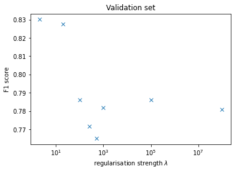

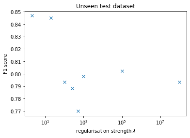

```python
plt.plot(reg_strs,scan_val,'x',label='validation train')
plt.title('Validation set')
plt.xlabel('regularisation strength $\lambda$')
plt.ylabel('F1 score')
plt.xscale('log')
plt.show()
plt.plot(reg_strs,scan_test,'x',label='test')
plt.title('Unseen test dataset')
plt.xlabel('regularisation strength $\lambda$')
plt.ylabel('F1 score')
plt.xscale('log')
plt.show()
```

We clearly see from the quality of the predictions based on the F1 score that the model performs best with a small regularisation strength, 2 and 20 being the best on both training (validation folds) and unseen test datasets. This suggests that a linear hard margin SVM (with high regularisation strength) may not be the best way to build a model for this kind of high-dimensional dataset.

Before trying the soft-margin SVM, another method to tackle is to find a suitable kernel that will project our data points into an extra dimension and attempt to define a hyperplane that separates them in that space. Importantly, this extra dimension is defined solely using the values of the original dimensions, so we must be careful about defining it so that it suits well our dataset and, importantly, future datasets. This is done by taking advantage of the data values in the lower conditions and 'express' some properties that differentiate the +1 and -1 predictions which in turn allows to define a good hyperplane that separates the data well.

#### ii) Radial Basis Function kernel SVM

We now implement the hard margin non-linear kernel SVM with radial basis function (RBF) kernel and do a grid search to find the optimal hyperparameter. To keep the margin hard, we penalise the misclassifications (unreasonably) harshly and keep the regularisation parameter very high, $\lambda = 10^5$. The kernel allows to compute an extra dimension of the data, thus adding an extra dimension to the hyperplane that will separate it. The choice of the kernel is crucial here, especially with high-dimensional datta as it needs to take advantage of the existing coordinates to make their properties more 'expressed'. If the Gaussian kernel is suitable, we should expect a better performance than the linear SVM, but this is not necessarily the case if the data is not clustered nicely even with the extra dimension.

There are some crucial changes in the computation of the predictions. We first replace the dot product operations with the kernel function. Also, we do not have the weights as in the linear case because we are defining the hyper-plane in higher dimensions by using the kernel. This means that the weights in the kernelised SVM are not as directly related to the input space.

We will use the coefficients $\alpha$ to compute the predictions. We will also need compute the hyperplane bias $b$ explicitly and not 'on the fly' as the last entry of W, as we did it for the linear case. This is becausee it is not involved in the kernel multiplication.

Moreover, using the kernel trick makes thee optimisation problem dual - therefore we need more advanced optimisation such as quadratic programming or linear programming with inequalities to solve this problem. This is because when we switch to the kernelised SVM, we optimise over the space of the number of data points (rows), while in the linear SVM we only need to optimise over the (much smaller) space of the number of features (columns).

Now compute the radial basis kernel with the hyperparameter $\sigma$ (default is 0.5) that we will need to optimise using the five-fold cross-validation. Note that we need to optimise to avoid overfitting which happens for small values of $\sigma$. (Source: "Kernels", MIT 15.097 Course Notes by Cynthia Rudin, URL: https://ocw.mit.edu/courses/sloan-school-of-management/15-097-prediction-machine-learning-and-statistics-spring-2012/lecture-notes/MIT15_097S12_lec13.pdf)

```python
def rbf_kernel(x,y,sigma):
    return np.exp((-np.linalg.norm(x-y)**2)/sigma)
```

Compare the dot product and the kernel function - notice that the kernel never goes above 1. This suggests that in the prediction, we need to explicitly add the intercept b and not include it in the kernel calculations which we sum up over the number of the support vectors that define the hyperplane. Naively substituting the dot product by the kernel in the prediction function would give us all predictions as 1, beecause the sign of any value of the exponent function (which is how we define the kernel) is positive.

```python
x = np.array([1,-2,-3,-4,-5])
y = np.array([9,4,7,2,6])
print(np.dot(x,y))
print(rbf_kernel(x,y,100))
```

```
-58
0.02815585368030008
```

```python
# define function to calculate hinge loss
def compute_cost_kernel(W, X, y, sigma, regul_strength=1e5):
    n = X.shape[0]
    distances = 1 - y * (rbf_kernel(X, W, sigma))
#     distances = 1 - y * (rbf_kernel(X[:,:-1], W[:-1], sigma))  # if we do the intercept b separation
    distances[distances < 0] = 0  # equivalent to max(0, distance)
    hinge = regul_strength * (np.sum(distances) / n) # calculate the hinge loss function
    # calculate cost
    cost = 1 / 2 * np.dot(W, W) + hinge
    return cost
```

Below is an attempt to implement the algorithm with the derivative of the kernel because we need to separate the intercept b which is not in the higher dimensional space - the goal is to optimise the weights that define the hyperplane and the intercept b separately. However it takes up a lot of computational power, so it could not be used for scanning over the parameters sigma. For the parameters of sigma that were tried out, it gives out all predictions of 1's.

```python
# calculate gradient of cost
def derivative_kernel(W, x_i, sigma):
    return rbf_kernel(W,x_i,sigma)* ((-2/sigma) * (W-x_i))


def calculate_cost_gradient_kernel_costly(W, X_batch, y_batch, sigma, regul_strength=1e5):
    # if only one example is passed
    if type(y_batch) == np.float64:
        y_batch = np.asarray([y_batch])
        X_batch = np.asarray([X_batch])  # gives multidimensional array
    distance = 1 - (y_batch * rbf_kernel(X_batch[:,:-1], W[:-1], sigma))
    dw = np.zeros(len(W[:-1]))
    db = 0

    for ind, d in enumerate(distance):
        if max(0, d)==0:
            dw += W[:-1]
            db -= 0
        else:
            dw += W[:-1] - (regul_strength * y_batch[ind] * derivative_kernel(W[:-1], X_batch[ind][:-1], sigma))
            db -= regul_strength * y_batch[ind]  # update the gradient of b to optimise b implicitly

    dw = dw/len(y_batch)  # average it
    db = db/len(y_batch)

    return dw, db
```

Instead, we perform the optimisation using this gradient descent function.

```python
# calculate gradient of cost
def calculate_cost_gradient_kernel(W, X_batch, y_batch, sigma, regul_strength=1e5):
    # if only one example is passed
    if type(y_batch) == np.float64:
        y_batch = np.asarray([y_batch])
        X_batch = np.asarray([X_batch])  # gives multidimensional array

    distance = 1 - (y_batch * rbf_kernel(X_batch, W, sigma))
    dw = np.zeros(len(W))

    for ind, d in enumerate(distance):
        if max(0, d)==0:
            di = W
        else:
            di = W - (regul_strength * y_batch[ind] * X_batch[ind])
        dw += di

    dw = dw/len(y_batch)  # average
    return dw
```

```python
def sgd_kernel(X, y, sigma, max_iterations=2000, stop_criterion=0.01, learning_rate=1e-5, regul_strength=1e5, print_outcome=False):
  # write the initial conditions for the weights
  weights = np.zeros(X.shape[1])
  nth = 0
  # initialise starting cost as infinity
  prev_cost = np.inf

  # stochastic gradient descent
  for iteration in range(1, max_iterations):
      # shuffle to prevent repeating update cycles
      np.random.shuffle([X, y])
      for ind, x in enumerate(X):
          ascent = calculate_cost_gradient_kernel(weights, x, y[ind], sigma, regul_strength)
          weights = weights - (learning_rate * ascent) # use the gradients of w in ascent for hyperplane optimisation


#           if using the separation of weights and intercept b to optimise it implicitly, using the gradient of b for intercept optimisation
#           ascent_w, db = calculate_cost_gradient_kernel_costly(weights, x, y[ind], sigma, regul_strength)
#           weights[:-1] = weights[:-1] - (learning_rate * ascent_w)  # use the gradients of w for hyperplane optimisation
#           weights[-1] = weights[-1] - (learning_rate * db)  # use the gradient of b for intercept optimisation


      # convergence check on 2^n'th iteration
      if iteration==2**nth or iteration==max_iterations-1:
          # compute cost
          cost = compute_cost_kernel(weights, X, y, sigma, regul_strength)
          if print_outcome:
            print("Iteration is: {}, Cost is: {}".format(iteration, cost))
          # stop criterion
          if abs(prev_cost - cost) < stop_criterion * prev_cost:
              return weights

          prev_cost = cost
          nth += 1

  return weights
```

Define a function to get the prediction for the kernelised SVM.

```python
def predict_rgd_SVM(W, X, y, sigma):
    y_preds = np.array([])
    for i in range(X.shape[0]):
        y_pred = np.sign(  rbf_kernel(X[i,:-1], W[:-1], sigma) + np.dot(X[i,-1],W[-1]) )  # W[-1] is the intercept b of the hyperplane

#         y_pred = np.sign(  rbf_kernel(X[i,:-1], W[:-1], sigma) + W[-1])
#         y_pred = np.sign(np.dot(X[i], W))
        y_preds = np.append(y_preds, y_pred)
    return y_preds
```

Run the model

```python
W = sgd_kernel(X_111.to_numpy(), y_111.to_numpy(), sigma=0.5, max_iterations=2000, stop_criterion=0.01, learning_rate=1e-3, regul_strength=1e5, print_outcome=True)
print("Training finished.")
print(W)
```

[output not shown]

We now get the prediction for the training data. What happens here is that out prediction is determined by the sign of the intercept b, while the kernel is equal to zero. This gives us all predictions of 1's. I suspect the optimisation in the gradient descent is faulty in the functions I defined.

```python
# get prediction for training data
y_pred = predict_rgd_SVM(W,X_111.to_numpy(),y_111.to_numpy(), sigma=0.5)
print(y_pred)
y_actual = y_111
# get F1 score for training data
print('Training data')
tp, fp, tn, fn = confusion_matrix(y_actual,y_pred)
precision, recall = prec_rec(tp, fp, tn, fn)
print('Precision :',precision)  # positive predictive value
print('Recall :', recall)  # sensitivity
F1 = f1_score(precision, recall)
```

[output not shown]

```python
# get prediction for test data
y_pred = predict_rgd_SVM(W,X_222.to_numpy(),y_222.to_numpy(),sigma=0.5)
y_actual = y_222
# get F1 score for training data
print('Test data')
tp, fp, tn, fn = confusion_matrix(y_actual,y_pred)
precision, recall = prec_rec(tp, fp, tn, fn)
F1 = f1_score(precision, recall)
```

```
Test data
TP: 147 FP: 53 TN: 0 FN: 0
F1 score : 0.8472622478386168
```

```python
# get prediction for test data
y_pred = predict_rgd_SVM(W,X_222.to_numpy(),y_222.to_numpy(),sigma=0.1)
y_actual = y_2
# get F1 score for training data
print('Test data')
tp, fp, tn, fn = confusion_matrix(y_actual,y_pred)
precision, recall = prec_rec(tp, fp, tn, fn)
F1 = f1_score(precision, recall)
```

```
Test data
TP: 147 FP: 53 TN: 0 FN: 0
F1 score : 0.8472622478386168
```

Now perform the grid search and 5-fold CV.

```python
def cross_val_evaluate(data, data_test, num_folds, sigma):
  folds = cross_val_split(data, num_folds)
  F1_scores = []
  F1_test = []
  TPR_test = []
  FPR_test = []
  for i in range(len(folds)):
    #print('Fold', i+1)
    # define the training set
    train_set = np.delete(np.asarray(folds).reshape(len(folds), folds[0].shape[0], folds[0].shape[1]), i, axis=0)
    train_folds = train_set.reshape(len(train_set)*train_set[0].shape[0], train_set[0].shape[1])

    X_train = train_folds[:,:-1]
    y_train = train_folds[:,-1]

    # define the validation set
    val_fold = folds[i]
    X_val = val_fold[:,:-1]
    y_val = val_fold[:,-1]

    X_test = data_test[:,:-1]
    y_test = data_test[:,-1]

    # train the model
    W = sgd_kernel(X_train, y_train, sigma=0.5, max_iterations=2000, stop_criterion=0.01, learning_rate=1e-3, regul_strength=1e7, print_outcome=False)

    # get y_pred
    y_pred = predict_rgd_SVM(W,X_val,y_val,sigma)
    # get y_pred
    y_pred_test = predict_rgd_SVM(W,X_test,y_test,sigma)


    # evaluate with F1 score on the validation fold
    tp, fp, tn, fn = confusion_matrix(y_val,y_pred,print_info=False)
    precision, recall = prec_rec(tp, fp, tn, fn)
    F1 = f1_score(precision, recall,print_info=False)
    F1_scores.append(F1)

    # evaluate with F1 score on the test set
    tp_test, fp_test, tn, fn = confusion_matrix(y_test,y_pred_test,print_info=False)
    precision, recall = prec_rec(tp, fp, tn, fn)

    F1_t = f1_score(precision, recall,print_info=False)
    F1_test.append(F1_t)

    TPR_test.append(recall)
    fpr = fp / (fp + tn) if (fp + tn)!=0 else 0
    FPR_test.append(fpr)


  return F1_scores, F1_test, TPR_test, FPR_test
```

```python
sigmas = np.linspace(0.0001,15,20)
print(sigmas)
```

```
[1.00000000e-04 7.89568421e-01 1.57903684e+00 2.36850526e+00
 3.15797368e+00 3.94744211e+00 4.73691053e+00 5.52637895e+00
 6.31584737e+00 7.10531579e+00 7.89478421e+00 8.68425263e+00
 9.47372105e+00 1.02631895e+01 1.10526579e+01 1.18421263e+01
 1.26315947e+01 1.34210632e+01 1.42105316e+01 1.50000000e+01]
```

```python
scan = []
scan_test = []
TPR_test_list = []
FPR_test_list = []

for s in sigmas:
    print('sigma',s,'...')
    F1_scores, F1_test, TPR_test, FPR_test = cross_val_evaluate(data_train, data_test, 5, s)
    TPR_test_list.append(TPR_test)
    FPR_test_list.append(FPR_test)
    scan.append(np.average(F1_scores))
    scan_test.append(np.average(F1_test))
```

```
sigma 0.0001 ...
sigma 0.7895684210526316 ...
sigma 1.5790368421052632 ...
sigma 2.368505263157895 ...
sigma 3.1579736842105266 ...
sigma 3.9474421052631583 ...
sigma 4.736910526315789 ...
sigma 5.526378947368421 ...
sigma 6.3158473684210525 ...
sigma 7.105315789473684 ...
sigma 7.894784210526316 ...
sigma 8.684252631578948 ...
sigma 9.473721052631578 ...
sigma 10.26318947368421 ...
sigma 11.052657894736843 ...
sigma 11.842126315789473 ...
sigma 12.631594736842105 ...
sigma 13.421063157894737 ...
sigma 14.210531578947368 ...
sigma 15.0 ...
```

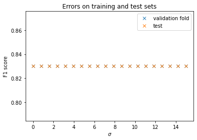

```python
plt.plot(sigmas,scan,'x',label='validation fold')
plt.plot(sigmas,scan_test,'x',label='test')
plt.title('Errors on training and test sets')
plt.xlabel('$\sigma$')
plt.ylabel('F1 score')
plt.legend()
plt.show()
```

We see that in each of the five folds, the predictions are always 1, thus even modifying the parameter of the kernel does not change it. In addition to the kernel being set to 0 and the intercept b being positive thus making the prediction 1, it is useful to think why we get the positive value of b in this case. It may be due to the predictions in training data being generally 1's, while the folds are smaller subsets of the training data, and the hard-margin SVMs does not separate well data that is non-linearly separable.

Since the scores do not change, there is not much use to compute the ROC curve as there is no rates of false positives against the true positives as they remain constant. It would be much more meaningful if we drew it having varying rates of false positives and true negatives, because in that case we could see how well out model is distinguishing between the classes, verying the hyperparameters. It would be most reasonable to choose the hyperparameters for which the true positive rate is largest and falsee positive rate is smallest - that is the point where the line of FP rate and TP rate is furthest from the random diagonal line which represents random sampling.

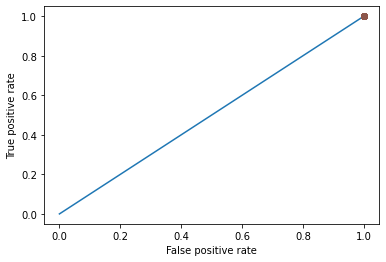

```python
ident = [0.0, 1.0]
plt.plot(ident,ident)
plt.plot(FPR_test_list,TPR_test_list,'o')
plt.xlabel('False positive rate')
plt.ylabel('True positive rate')
plt.show()
```

We can see that the point at 1,1 is not better than random sampling, and this is due to the fact that we get all predictions as 1's.

It may also be that the Gaussian kernel is not well suited for this dataset. It is may be non-separable even after implementing the Gaussian kernel trick as we have high-dimensional variables. However, additional checks and alternative implementations of optimisation would be helpful to explore the data and determine whether it is more suitable for the kernelised SVM.

Additionally, the issue may be the implementation of stochastic gradient descent, it would have been useful to implement the same calculations with Quadratic Programming packages for convex optimisation to use the alphas (Lagrange multipliers) directly to determine the support vectors that will contribute to the definition of the hyperplane. The support vectors will correspond to non-zero alpha terms, using the complimentary slackness condition. Below is a sketch of the implementation. (I started doing this before the instructors specified that we are not allowed to use optimisation packages)

```python
def model():
    # perform QP (cvxopt package for example) with our constraint, get the alphas
    # get the support vectors y_sv
    # get the sub-kernel matrix K, where K[i,j] = rbf_kernel(X[i], X[j])
    # get sv are the indices of the suppoort vectors
    # calculate the intercept b explicitly looping through the support vectors
    for k in range(sum(sv)): # number of support vectors sv
        b = b + y_sv[k] - np.sum(K[indices[k],sv] * alpha * y_sv) # calculate the intercept b explicitly
                                                                # using the non-zero Lagrange multipliers alpha
                                                                # and the sub-kernels for that support vector
    return sv, b
```

```python
# define a prediction function for kernel SVMs
# the prediction is the sign of the output of this function: kernel(x,w) + b
def predict_kerSVM(X, y, alpha, support_vectors, b):
    y_preds = np.array([])
    for i in range(X.shape[0]):
        sum = 0
        for j in range(len(support_vectors)):  # no assumption that we have two support vectors here
            sum = sum + alpha[j] * y[j] * rbf_kernel(x,support_vectors[j],sigma=0.5) #np.sign(np.dot(X[i], W))
        y_pred = sum + b  # add the intercept b explicitly
        y_preds = np.append(y_preds, y_pred)
    return y_preds
```

## Mastery Component

#### Hard vs Soft margin

In our implementation, we retrieve the hard margin for high regularisation strengths, while for smaller ones we have a soft margin.

For a $\lambda$ that is too small, the model is not 'punished' for the errors enough, so expect the model to be too general and not fit well, and for a large $\lambda$, the importance of the error is inflated and we get good in-sample accuracy but we overfit the data. We have already seen in the exploration before the implementation of the hard-margin SVM that we do get higher accuracy in both the training and test sets with a small regularisation strength. We will now explore this in more detail, using the sigmoid kernel (multilayer perceptron) in the comparison of the hard and soft margin SVMs.

The sigmoid kernel is most commonly described in the literature as only being positive definite (a must condition for extra-dimensionality in this case) for some parameter values, and in general it is not seen as better than RBF or linear kernels. (Source: "A Study on Sigmoid Kernels for SVM and the Training of non-PSD Kernels by SMO-type Methods", Hsuan-Tien Lin and Chih-Jen Lin, National Taiwan University, URL: http://home.caltech.edu/~htlin/publication/doc/tanh.pdf)

```python
# parameters - slope (commonly 1/N, N is the dimension of data) and intercept c
def kernel_sigmoid(x,y,slope,c):
    return np.tanh(-slope*np.dot(x,y)+c)
```

```
-3
0.5153592780074097
```

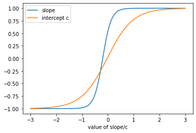

```python
x = np.array([2,2,-3,5,1,5,6,8,3,4])
y = np.array([1,1,1,-1,-1,1,1,-1,1,-1])
print(np.dot(x,y))
print(kernel_sigmoid(x,y,-0.01,0.6))

check_slope = []
check_intercept = []
ran = np.arange(-3,3,0.001)
for i in ran:
    check_slope.append(kernel_sigmoid(x,y,i,0.6))
    check_intercept.append(kernel_sigmoid(x,y,0.01,i))
plt.plot(ran,check_slope, label='slope')
plt.plot(ran,check_intercept, label='intercept c')
plt.xlabel('value of slope/c')
plt.legend()
plt.show()
```

In this graph, we explore thee behaviour of the kernel function and its sensitivity to the variations of the hyperparameters. These graphs are not ideal because in each scanning, we had set the other hyperparameter as constant. Notice however that there is a more dramatic change from -1 to 1 when we vary the slope. Although of course depending on the input vectors, we can also get a positive value when the slope or c is negative.

Interestingly, it has been shown that when the slope and intercept c are in a certain limited range for some a > 0, r < 0, we essentially have a similar behaviour to the RBF kernel. (Source: https://www.csie.ntu.edu.tw/~cjlin/papers/tanh.pdf)

##### define the functions with sigmoid kernel

```python
# define function to calculate hinge loss
def compute_cost_sigmoid(W, X, y, slope, c, regul_strength):
    n = X.shape[0]
    distances = 1 - y * (kernel_sigmoid(X, W, slope=0.01, c=0.25))
    distances[distances < 0] = 0  # equivalent to max(0, distance)
    hinge = regul_strength * (np.sum(distances) / n) # calculate the hinge loss function
    # calculate cost
    cost = 1 / 2 * np.dot(W, W) + hinge
    return cost
```

```python
# calculate gradient of cost
def calculate_cost_gradient_sigmoid(W, X_batch, y_batch, slope, c, regul_strength):
    if type(y_batch) == np.float64:      # if only one example is passed
        y_batch = np.asarray([y_batch])
        X_batch = np.asarray([X_batch])  # gives multidimensional arry
    distance = 1 - (y_batch * kernel_sigmoid(X_batch, W, slope, c))
    dw = np.zeros(len(W))

    for ind, d in enumerate(distance):
        if max(0, d)==0:
            di = W
        else:
            di = W - (regul_strength * y_batch[ind] * X_batch[ind])
        dw += di
    dw = dw/len(y_batch)  # average
    return dw
```

```python
# define stochastic gradient descent to get weights that define our hyperplane

def sgd_sigmoid(X, y, slope, c, max_iterations=2000, stop_criterion=0.01, learning_rate=1e-5, regul_strength=1e5, print_outcome=False):
  # write the initial conditions for the weights
  weights = np.zeros(X.shape[1])
  nth = 0
  prev_cost = np.inf  # initialise starting cost as infinity
  for iteration in range(1, max_iterations):  # stochastic gradient descent
      np.random.shuffle([X, y])  # shuffle to prevent repeating update cycles
      for ind, x in enumerate(X):
          ascent = calculate_cost_gradient_sigmoid(weights, x, y[ind], slope, c, regul_strength)
          weights = weights - (learning_rate * ascent)

      # convergence check on 2^n'th iteration
      if iteration==2**nth or iteration==max_iterations-1:
          # compute cost
          cost = compute_cost_sigmoid(weights, X, y, slope, c, regul_strength)
          if print_outcome:
            print("Iteration is: {}, Cost is: {}".format(iteration, cost))
          # stop criterion
          if abs(prev_cost - cost) < stop_criterion * prev_cost:
              return weights

          prev_cost = cost
          nth += 1

  return weights
```

```python
# define prediction function
def predict_sigmoid_SVM(W, X, y, slope, c):
    y_preds = np.array([])
    for i in range(X.shape[0]):
        y_pred = np.sign( kernel_sigmoid(X[i,:-1], W[:-1], slope, c) + np.dot(X[i,-1],W[-1]) )  # W[-1] is the intercept b of the hyperplane

#         y_pred = np.sign(  kernel_sigmoid(X[i,:-1], W[:-1], slope, c) + W[-1])
#         y_pred = np.sign(np.dot(X[i], W))
        y_preds = np.append(y_preds, y_pred)
    return y_preds
```

```python
W_hard = sgd_sigmoid(X_11.to_numpy(), y_11.to_numpy(), slope=1/len(X_11), c=0.25, max_iterations=2000, stop_criterion=0.01, learning_rate=1e-3, regul_strength=1e6, print_outcome=True)
print("Training finished.")
print(W_hard)
W_soft = sgd_sigmoid(X_11.to_numpy(), y_11.to_numpy(), slope=1/len(X_11), c=0.25, max_iterations=2000, stop_criterion=0.01, learning_rate=1e-3, regul_strength=0.001, print_outcome=True)
print("Training finished.")
print(W_soft)
```

```
Iteration is: 1, Cost is: 72432041707.7819
Iteration is: 2, Cost is: 164412536151.2869
Iteration is: 4, Cost is: 247335289067.93423
Iteration is: 8, Cost is: 270692060393.77765
Iteration is: 16, Cost is: 271715349827.50348
Training finished.
[-353011.61416195  238999.14464289 -318635.08876248   87231.37616646
  138968.74444795   34894.10192111 -392725.15899001  139653.13552984
 -217359.1474215  -105080.24546039]
Iteration is: 1, Cost is: 0.0008971598525049202
Iteration is: 2, Cost is: 0.0008971875597396048
Training finished.
[-1.34050092e-04  1.30539355e-04 -7.60064723e-05  1.07761067e-04
  7.92800031e-05 -3.01811658e-05 -1.44278664e-04  1.17895205e-04
 -9.40856058e-05  3.41809772e-05]
```

```python
# get prediction for test data
# X_2=X_2.to_numpy()
# y_2=y_2.to_numpy()

y_pred_h_test = predict_sigmoid_SVM(W_hard,X_22.to_numpy(),y_22.to_numpy(),slope=1/len(y_22), c=0.25)
y_pred_s_test = predict_sigmoid_SVM(W_soft,X_22.to_numpy(),y_22.to_numpy(),slope=1/len(y_22), c=0.25)
y_actual_test = y_2
# get F1 score for training data
print('Test data')
print('hard margin')
tp, fp, tn, fn = confusion_matrix(y_actual_test,y_pred_h_test)
precision, recall = prec_rec(tp, fp, tn, fn)
F1 = f1_score(precision, recall)
print('soft margin')
tp, fp, tn, fn = confusion_matrix(y_actual_test,y_pred_s_test)
precision, recall = prec_rec(tp, fp, tn, fn)
F1 = f1_score(precision, recall)
```

```
Test data
hard margin
TP: 82 FP: 30 TN: 23 FN: 65
F1 score : 0.6332046332046333
soft margin
TP: 147 FP: 53 TN: 0 FN: 0
F1 score : 0.8472622478386168
```

```python
W_hard = sgd_sigmoid(X_11.to_numpy(), y_11.to_numpy(), slope=5/len(X_11), c=0.9, max_iterations=2000, stop_criterion=0.01, learning_rate=1e-3, regul_strength=1e7, print_outcome=True)
print("Training finished.")
print(W_hard)
W_soft = sgd_sigmoid(X_11.to_numpy(), y_11.to_numpy(), slope=5/len(X_11), c=0.9, max_iterations=2000, stop_criterion=0.01, learning_rate=1e-3, regul_strength=0.01, print_outcome=True)
print("Training finished.")
print(W_soft)
```

```
Iteration is: 1, Cost is: 7784333020868.32
Iteration is: 2, Cost is: 16959485649488.645
Iteration is: 4, Cost is: 24885383099194.438
Iteration is: 8, Cost is: 27053103625557.992
Iteration is: 16, Cost is: 27160840630827.484
Training finished.
[-3549298.72097779  2383094.53569615 -3196143.11874511   825764.28679378
  1351319.75282191   328678.87186131 -3928276.98032873  1392426.44338418
 -2162214.35658338 -1080879.71514117]
Iteration is: 1, Cost is: 0.008973910689910729
Iteration is: 2, Cost is: 0.008976681413993551
Training finished.
[-0.0013405   0.00130539 -0.00076006  0.00107761  0.0007928  -0.00030181
 -0.00144279  0.00117895 -0.00094086  0.00034181]
```

```python
y_pred_h_test = predict_sigmoid_SVM(W_hard,X_22.to_numpy(),y_22.to_numpy(),slope=1/len(y_22), c=0.00002)
y_pred_s_test = predict_sigmoid_SVM(W_soft,X_22.to_numpy(),y_22.to_numpy(),slope=1/len(y_22), c=0.00002)
y_actual_test = y_2
# get F1 score for training data
print('Test data')
print('hard margin')
tp, fp, tn, fn = confusion_matrix(y_actual_test,y_pred_h_test)
precision, recall = prec_rec(tp, fp, tn, fn)
F1 = f1_score(precision, recall)
print('soft margin')
tp, fp, tn, fn = confusion_matrix(y_actual_test,y_pred_s_test)
precision, recall = prec_rec(tp, fp, tn, fn)
F1 = f1_score(precision, recall)
```

```
Test data
hard margin
TP: 82 FP: 30 TN: 23 FN: 65
F1 score : 0.6332046332046333
soft margin
TP: 65 FP: 23 TN: 30 FN: 82
F1 score : 0.5531914893617021
```

The results for the hard margin seem to be independent from the parameters, but in the soft margin case, varying the intercept does seem to affect the balance between the posittive and negative predictions: for positive values, we get all positive predictions on the testing set, for very small (of order $10^{-5}$) positive and negative values, we have a combination of both positive and negative predictions, while for negative values we only get negative predictions (-1 corresponding to dependent classification variable 0).

In what follows, we will perform a grid parameter search with 5-fold cross-validation on the soft margin sigmoid kernel SVM model to find the optimal hyperparameters.

```python
def cross_val_evaluate_sigmoid(data, data_test, num_folds, regul_strength, slope, c, print_info = True):
  folds = cross_val_split(data, num_folds)
  F1_scores = []
  F1_test = []
  for i in range(len(folds)):
    if print_info:
        print('Fold', i+1)
    # define the training set
    train_set = np.delete(np.asarray(folds).reshape(len(folds), folds[0].shape[0], folds[0].shape[1]), i, axis=0)
    train_folds = train_set.reshape(len(train_set)*train_set[0].shape[0], train_set[0].shape[1])

    X_train = train_folds[:,:-1]
    y_train = train_folds[:,-1]

    # define the validation set
    val_fold = folds[i]
    X_val = val_fold[:,:-1]
    y_val = val_fold[:,-1]

    X_test = data_test[:,:-1]
    y_test = data_test[:,-1]

    # train the model
    W = sgd_sigmoid(X_train,y_train, slope, c, max_iterations=2000,
                    stop_criterion=0.01, learning_rate=1e-3, regul_strength=0.01, print_outcome=print_info)
    # get y_pred
    y_pred = predict_sigmoid_SVM(W,X_val,y_val,slope,c)
    # get y_pred
    y_pred_test = predict_sigmoid_SVM(W,X_test,y_test,slope,c)

    # evaluate with F1 score on the validation fold
    tp, fp, tn, fn = confusion_matrix(y_val,y_pred,print_info=False)
    precision, recall = prec_rec(tp, fp, tn, fn)
    F1 = f1_score(precision, recall,print_info=False)
    F1_scores.append(F1)

    # evaluate with F1 score on the test set
    tp, fp, tn, fn = confusion_matrix(y_test,y_pred_test,print_info=False)
    precision, recall = prec_rec(tp, fp, tn, fn)
    F1_t = f1_score(precision, recall,print_info=False)
    F1_test.append(F1_t)



  return F1_scores, F1_test
```

```python
# init candidate hyperparameters, we have default regul_strength as 0.01 for the soft margin

slope = 1/800
# cs = [-0.01,-0.001,-0.0008,-0.0005,-0.0003,0]
cs = np.arange(-0.004,0-0.0025,0.00001)

hyperparams = [0,0]

scan = []
scan_test = []
for c in cs:
    print('c =',c)
    F1_scores, F1_test = cross_val_evaluate_sigmoid(data_train, data_test, 5, 0.01, slope, c)
    scan.append(np.average(F1_scores))
    scan_test.append(np.average(F1_test))
```

```
c = -0.004
Fold 1
Iteration is: 1, Cost is: 0.008955372077610933
Iteration is: 2, Cost is: 0.00896048615034294
TP: 0 FP: 0 TN: 49 FN: 111
F1 score : 0
TP: 0 FP: 0 TN: 53 FN: 147
F1 score : 0
Fold 2
Iteration is: 1, Cost is: 0.008940050832452426
Iteration is: 2, Cost is: 0.00894514708934767
TP: 0 FP: 0 TN: 51 FN: 109
F1 score : 0
TP: 0 FP: 0 TN: 53 FN: 147
F1 score : 0
Fold 3
Iteration is: 1, Cost is: 0.00895543195326053
Iteration is: 2, Cost is: 0.008960623886081315
TP: 0 FP: 0 TN: 49 FN: 111
F1 score : 0
TP: 0 FP: 0 TN: 53 FN: 147
F1 score : 0
Fold 4
Iteration is: 1, Cost is: 0.009009107853185915
Iteration is: 2, Cost is: 0.009014429633772615
TP: 0 FP: 0 TN: 42 FN: 118
F1 score : 0
TP: 0 FP: 0 TN: 53 FN: 147
F1 score : 0
Fold 5
Iteration is: 1, Cost is: 0.009016642425011795
Iteration is: 2, Cost is: 0.009021808947850258
TP: 0 FP: 0 TN: 41 FN: 119
F1 score : 0
TP: 0 FP: 0 TN: 53 FN: 147
F1 score : 0
c = -0.0039900000000000005
Fold 1
Iteration is: 1, Cost is: 0.008955372077610933
Iteration is: 2, Cost is: 0.00896048615034294
```

[output cut: 5345 more lines]

```
F1 score : 0.8472622478386168
Fold 4
Iteration is: 1, Cost is: 0.009009107853185915
Iteration is: 2, Cost is: 0.009014429633772615
TP: 118 FP: 42 TN: 0 FN: 0
F1 score : 0.8489208633093526
TP: 147 FP: 53 TN: 0 FN: 0
F1 score : 0.8472622478386168
Fold 5
Iteration is: 1, Cost is: 0.009016642425011795
Iteration is: 2, Cost is: 0.009021808947850258
TP: 119 FP: 41 TN: 0 FN: 0
F1 score : 0.8530465949820789
TP: 147 FP: 53 TN: 0 FN: 0
F1 score : 0.8472622478386168
```

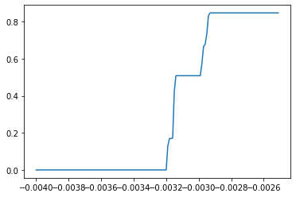

```python
plt.plot(cs,scan_test)
plt.xaxis('intercept c')
plt.yaxis('F1 score')
plt.show()
```

We do seem to get different F1 scores when we vary the c intercept parameter in the sigmoid kernel function, but it does not reach better accuracies than the prediction where we get all positive preedictions. This suggests there may be fundamental flaws in the optimisation method or in the tuning of other parameters that were not considered in the optimisation.

```python
slopes = np.arange(-10,1,0.1)
# cs = [-0.01,-0.001,-0.0008,-0.0005,-0.0003,0]
c = 0.01

hyperparams = [0,0]

scan = []
scan_test = []
for sl in slopes:
    print('slope =',sl)
    F1_scores, F1_test = cross_val_evaluate_sigmoid(data_train, data_test, 5, 0.01, sl, c)
    scan.append(np.average(F1_scores))
    scan_test.append(np.average(F1_test))
```

```
slope = -10.0
Fold 1
Iteration is: 1, Cost is: 0.008955372077610933
Iteration is: 2, Cost is: 0.00896048615034294
TP: 84 FP: 22 TN: 27 FN: 27
F1 score : 0.7741935483870969
TP: 103 FP: 22 TN: 31 FN: 44
F1 score : 0.7573529411764706
Fold 2
Iteration is: 1, Cost is: 0.008940050832452426
Iteration is: 2, Cost is: 0.00894514708934767
TP: 83 FP: 26 TN: 25 FN: 26
F1 score : 0.7614678899082569
TP: 102 FP: 19 TN: 34 FN: 45
F1 score : 0.7611940298507464
Fold 3
Iteration is: 1, Cost is: 0.00895543195326053
Iteration is: 2, Cost is: 0.008960623886081315
TP: 83 FP: 20 TN: 29 FN: 28
F1 score : 0.7757009345794393
TP: 101 FP: 23 TN: 30 FN: 46
F1 score : 0.7453874538745388
Fold 4
Iteration is: 1, Cost is: 0.009009107853185915
Iteration is: 2, Cost is: 0.009014429633772615
TP: 86 FP: 18 TN: 24 FN: 32
F1 score : 0.7747747747747747
TP: 102 FP: 22 TN: 31 FN: 45
F1 score : 0.7527675276752769
Fold 5
Iteration is: 1, Cost is: 0.009016642425011795
Iteration is: 2, Cost is: 0.009021808947850258
TP: 86 FP: 19 TN: 22 FN: 33
F1 score : 0.7678571428571429
TP: 103 FP: 22 TN: 31 FN: 44
F1 score : 0.7573529411764706
slope = -9.9
Fold 1
Iteration is: 1, Cost is: 0.008955372077610933
Iteration is: 2, Cost is: 0.00896048615034294
```

[output cut: 3905 more lines]

```
F1 score : 0.8472622478386168
Fold 4
Iteration is: 1, Cost is: 0.009009107853185915
Iteration is: 2, Cost is: 0.009014429633772615
TP: 118 FP: 42 TN: 0 FN: 0
F1 score : 0.8489208633093526
TP: 147 FP: 53 TN: 0 FN: 0
F1 score : 0.8472622478386168
Fold 5
Iteration is: 1, Cost is: 0.009016642425011795
Iteration is: 2, Cost is: 0.009021808947850258
TP: 119 FP: 41 TN: 0 FN: 0
F1 score : 0.8530465949820789
TP: 147 FP: 53 TN: 0 FN: 0
F1 score : 0.8472622478386168
```

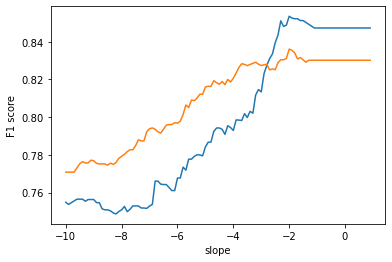

```python
plt.plot(slopes,scan_test,label='test set')
plt.plot(slopes, scan, label='validation set')
plt.xlabel('slope')
plt.ylabel('F1 score')
plt.show()
```

It looks like for a fixed value of intercept c that was shown to produce a better accuracy, (although only by making all predictions to be 1's, and this accuracy being high due to the data having a large number of 1's in general) we have better accuracy around the value -2.

We now perform a grid search over both hyperparameters:

```python
cs = np.arange(-0.0034,0.1,0.01)
slopes = np.arange(-5,1,0.4)

max_val = 0
max_test = 0
list_params_val = [0,0]  # [slope, c]
list_params_test = [0,0]
for c in cs:
    print('\nLoading for intercept c =',c,'...')
    for sl in slopes:
        F1_scores, F1_test = cross_val_evaluate_sigmoid(data_train, data_test, 5, 0.01, sl, c,print_info=False)
        F1_scores = np.average(F1_scores)
        if F1_scores>max_val:
            max_val = F1_scores
            list_params_val = [sl,c]

        F1_test = np.average(F1_test)
        print('slope',sl,'average testing accuracy',F1_test)
        if F1_test>max_test:
            max_test = F1_test
            list_params_test = [sl,c]
```

```
Loading for intercept c = -0.0034 ...
slope -5.0 average testing accuracy 0.6935630325337923
slope -4.6 average testing accuracy 0.6935630325337923
slope -4.199999999999999 average testing accuracy 0.6935630325337923
slope -3.799999999999999 average testing accuracy 0.6935630325337923
slope -3.3999999999999986 average testing accuracy 0.6941139967211202
slope -2.9999999999999982 average testing accuracy 0.6916901104888294
slope -2.599999999999998 average testing accuracy 0.6916901104888294
slope -2.1999999999999975 average testing accuracy 0.6916901104888294
slope -1.7999999999999972 average testing accuracy 0.6912032883206154
slope -1.3999999999999968 average testing accuracy 0.6879177975376753
slope -0.9999999999999964 average testing accuracy 0.6810317650830665
slope -0.5999999999999961 average testing accuracy 0.6513663171088837
slope -0.19999999999999574 average testing accuracy 0.5694881098239487
slope 0.20000000000000462 average testing accuracy 0.3845936421437508
slope 0.600000000000005 average testing accuracy 0.4491942159820427

Loading for intercept c = 0.0066 ...
slope -5.0 average testing accuracy 0.7660519359606912
slope -4.6 average testing accuracy 0.7626273545701228
slope -4.199999999999999 average testing accuracy 0.7718540026135827
slope -3.799999999999999 average testing accuracy 0.7799855967608706
slope -3.3999999999999986 average testing accuracy 0.7942183471913655
slope -2.9999999999999982 average testing accuracy 0.7929039012860969
slope -2.599999999999998 average testing accuracy 0.799781072526753
slope -2.1999999999999975 average testing accuracy 0.813577577934679
slope -1.7999999999999972 average testing accuracy 0.842178731652244
slope -1.3999999999999968 average testing accuracy 0.8520015211053366
slope -0.9999999999999964 average testing accuracy 0.8492269139205615
slope -0.5999999999999961 average testing accuracy 0.8472622478386167
slope -0.19999999999999574 average testing accuracy 0.8472622478386167
slope 0.20000000000000462 average testing accuracy 0.8472622478386167
slope 0.600000000000005 average testing accuracy 0.8472622478386167

Loading for intercept c = 0.0166 ...
slope -5.0 average testing accuracy 0.80305920537094
slope -4.6 average testing accuracy 0.8136112755622295
slope -4.199999999999999 average testing accuracy 0.8274713153353993
slope -3.799999999999999 average testing accuracy 0.8404590945514684
slope -3.3999999999999986 average testing accuracy 0.8495799162921399
```

[output cut: 131 more lines]

```
slope -5.0 average testing accuracy 0.8472622478386167
slope -4.6 average testing accuracy 0.8472622478386167
slope -4.199999999999999 average testing accuracy 0.8472622478386167
slope -3.799999999999999 average testing accuracy 0.8472622478386167
slope -3.3999999999999986 average testing accuracy 0.8472622478386167
slope -2.9999999999999982 average testing accuracy 0.8472622478386167
slope -2.599999999999998 average testing accuracy 0.8472622478386167
slope -2.1999999999999975 average testing accuracy 0.8472622478386167
slope -1.7999999999999972 average testing accuracy 0.8472622478386167
slope -1.3999999999999968 average testing accuracy 0.8472622478386167
slope -0.9999999999999964 average testing accuracy 0.8472622478386167
slope -0.5999999999999961 average testing accuracy 0.8472622478386167
slope -0.19999999999999574 average testing accuracy 0.8472622478386167
slope 0.20000000000000462 average testing accuracy 0.8472622478386167
slope 0.600000000000005 average testing accuracy 0.8472622478386167
```

```python
print(list_params_val)
print(list_params_test)
```

[output not shown]

These hyperparameters are not very meaningful since normally they are positive, and moreover the score that determines their choice is the one for the predictions of all 1's. This suggests that the implementation of the optimisation has errors.

### A state-of-the-art alternative to modifying the code provided

##### (in other words, a hacky way to implement the soft margin part of the Mastery material)

A way to go around the failing optimisation in the kernelised soft-margin SVM is to implement a different gradient descent method, namely the Pegasos algorithm, first introduced by Shalev-Shwartz et al. in 2011. (Source: Shalev-Shwartz, S., Singer, Y., Srebro, N. et al. Pegasos: primal estimated sub-gradient solver for SVM. Math. Program. 127, 3–30 (2011). https://doi.org/10.1007/s10107-010-0420-4)

The authors note that it is usually a constrained quadratic programming optimisation problem, but at its core, it originates from an unconstrained minimisation of the hinge loss function. In that paper, it has a slightly different formulation because the penalty term $\lambda$ is written for the norm of the vector $\boldsymbol w$ that is essentially our classification model: $$ L(\boldsymbol w) = \frac{\lambda}{2} \| \boldsymbol w \|^2 + \frac{1}{n} \sum_{i=1}^n l (\boldsymbol w, (\boldsymbol x, y)) \ $$ with $ l = \max \big( 0, 1-y_i \langle \boldsymbol w, \boldsymbol x \rangle ) \big)$ (*), and the inner product of w or x can be either linear or non-linear (kernelised). When kernelised, it is computed as $$ \langle \boldsymbol w, \boldsymbol x \rangle = \sum_{i\in I_t} \alpha_i \langle \boldsymbol x_i, \boldsymbol x_j \rangle, $$ and computing the norm of the weights that are the parameters of the separation hyperplane we seek to minimise also using the Lagrange multipliers alpha: $$ \| \boldsymbol w_t \|^2 = \sum_{i\in I_t} \alpha_i \alpha_j \langle \boldsymbol x_i, \boldsymbol x_j \rangle,$$ where the index $t$ represeents the fact that we are only training on a sub-sample of the training examples.

The crucial modification in this stochastic gradient descent method is that they do a projection step at each step of the calculation of the gradient. The projection is that of the weight w onto an L2 ball of radius $1/\sqrt{\lambda}$. Moreover, it does not use the full training examples, but only a sub-sample k of them to compute an approximate sub-gradient. This significantly reduces the computational power and allows for parallel computation. Also note that the learning rate is set to $\eta_t = \frac{1}{\lambda t}$.

The implementation of the for the linear and non-linear kernel case can be readily found on github for various programming languages; I rely on the pseudocode provided by the authors and a simple and straightforward implementation in the repository https://github.com/h44rd/Pegasos/blob/master/pegasos.py.

To better understand the updatee rule in this case, write thee update rules for the stochastic sub-gradient algorithm (it is stochastic because the training data is sampled at random):

if $ y_i f(\boldsymbol x_{i})<1:$ $$\boldsymbol w_{t+1} = \boldsymbol w_{t} - \eta(\lambda \boldsymbol w_{t} - y_i \boldsymbol x_{i}),$$ else: $$\boldsymbol w_{t+1} = \boldsymbol w_{t} - \eta \lambda \boldsymbol w_{t}, $$ where again $\eta$ is the learning rate.

Source: https://www.robots.ox.ac.uk/~az/lectures/ml/lect2.pdf

```python
# define the linear SVM algorithm - training and testing

def train_nonkernel(X_train, y_train, T, lam):
    t = 1
    w = np.zeros(X_test[0].shape)  # initialise the weights array
    idx = np.random.permutation(len(X_train)) # permute the order of the indices
    for i in idx:  # iterate through the indices
        x, yi = X_train[i], y_train[i]  # get the predictor and outcome at index i
        nt  = 1.0/(lam*t)  # nt is the learning rate, t is incremented after each iteration of the index
        # these conditionals correspond to the max function l defined above (*)
        if yi * np.dot(w, x) < 1:
            w = (1 - nt * lam) * w + nt * yi * x
        elif yi * np.dot(w, x) >= 1:
            w = (1 - nt * lam) * w
        w = min(1, (1/(lam)**(1/2))/np.linalg.norm(w)) * w  # update the weights depending on the penalty term
        t += 1
    return w  # return the weights

def test_nonkernel(w, X_test, y_test):
    total = 0
    correct = 0
    preds = []  # init list to store predictions
    for (x,yi) in zip(X_test, y_test):
        pred = np.dot(w, x)
        preds.append(pred)  # append prediction
        if yi * pred > 0:
            correct += 1
        total += 1
    return correct, total, np.sign(preds)  # output predictions as signs of the y to get -1,1 values
```

Prepare the data and parameters. Note that the performance of the algorithm depends on the parameter lambda and, importantly, does not depend on the size of the data.

```python
lam = 1 # lambda value
T = 1000 # number of iterations for training

# the input is numpy arrays without the extra column of 1's for the intercept b
X_train_peg = X_11.to_numpy()
y_train_peg = y_11.to_numpy()
X_test_peg = X_22.to_numpy()
y_test_peg = y_22.to_numpy()
```

Run the model

```python
w = train_nonkernel(X_train_peg, y_train_peg, 10000, lam)
correct, total, preds = test_nonkernel(w, X_test_peg, y_test_peg)
print('LINEAR SVM correct predictions:',correct,'total:',total, 'accuracy:', correct/total)
print('predictions:', preds)
```

```
LINEAR SVM correct predictions: 127 total: 200 accuracy: 0.635
predictions: [-1. -1. -1. -1. -1. -1.  1. -1. -1. -1. -1. -1.  1.  1.  1. -1. -1. -1.
  1. -1.  1. -1. -1.  1.  1. -1. -1. -1.  1.  1.  1.  1. -1.  1.  1. -1.
 -1. -1. -1. -1. -1.  1.  1.  1. -1. -1.  1.  1.  1.  1. -1. -1.  1.  1.
  1.  1.  1.  1.  1.  1. -1.  1.  1. -1. -1. -1.  1. -1.  1. -1. -1.  1.
  1. -1. -1.  1. -1.  1. -1. -1.  1. -1.  1.  1.  1. -1.  1.  1. -1.  1.
  1.  1.  1.  1. -1. -1.  1.  1.  1.  1.  1.  1.  1. -1.  1. -1. -1. -1.
 -1. -1.  1. -1. -1.  1. -1.  1. -1.  1. -1.  1.  1. -1.  1.  1.  1. -1.
  1. -1.  1. -1. -1.  1.  1.  1. -1.  1. -1. -1.  1.  1.  1.  1.  1. -1.
  1. -1.  1. -1.  1.  1. -1. -1. -1.  1.  1.  1.  1. -1.  1.  1.  1. -1.
 -1. -1. -1.  1.  1.  1.  1. -1. -1.  1.  1.  1. -1. -1.  1. -1.  1. -1.
  1.  1. -1. -1. -1. -1.  1.  1. -1.  1.  1. -1.  1.  1. -1. -1.  1.  1.
  1.  1.]
```

```python
# Evaluate F1 score on test data
tp, fp, tn, fn = confusion_matrix(y_test_peg,preds)
precision, recall = prec_rec(tp, fp, tn, fn)
F1_linear_test = f1_score(precision, recall)
```

```
TP: 91 FP: 17 TN: 36 FN: 56
F1 score : 0.7137254901960784
```

We seee that the F1 score of the linear SVM is not great, suggesting that our data is indeed non linearly separable. Implement the non-linear soft margin SVM with both the Gaussian and sigmoid kernels for a qualitative discussion about their performance.

```python
# define the gaussian RBF kernel
def kernel_rbf(x, y, sigma):
     return np.exp((-np.linalg.norm(x-y)**2)/sigma)

# parameters - slope (commonly 1/N, N is the dimension of data) and intercept c
def kernel_sigmoid(x,y,slope,c):
    return np.tanh(-slope*np.dot(x,y)+c)

def train_kernel(X_train, y_train, lam, T, sigma, slope, c, kernel):
    aplhas = np.zeros(len(X_train))
    idx = np.random.permutation(len(X_train)) # permute
    t = 0
    for i in idx:
        x, yi = X_train[i], y_train[i]
        s = 0
        for j in range(len(X_train)):
            if kernel=='rbf':
                s += aplhas[j]*y_train[j]*kernel_rbf(x, X_train[j], sigma)
            if kernel=='sigmoid':
                s += aplhas[j]*y_train[j]*kernel_sigmoid(x, X_train[j], slope, c)
        if yi*(1/lam)*s < 1:
            aplhas[i] = aplhas[i] + 1
        if t >= T:
            break
        else:
            t += 1
#         if t%100==0:
#             print("Iteration of Kernel Training: ", t)
    return aplhas  # return the alphas - the non-zero ones identify which support vectors define our separation hyperplane


def test_kernel(alphas, lam, X_test, y_test, X_train, y_train, T, sigma, slope, c, kernel):
    total = 0
    correct = 0
    t = 0
    preds = []
    for (x,yi) in zip(X_test, y_test):
        s = 0
        for j in range(len(X_train)):
            if kernel=='rbf':
                s += alphas[j]*y_train[j]*kernel_rbf(x, X_train[j], sigma)
            if kernel=='sigmoid':
                s += alphas[j]*y_train[j]*kernel_sigmoid(x, X_train[j], slope, c)
        if (yi*(1/lam)*s < 1):
            correct += 1
        preds.append(s)
        total += 1
        if t >= T:
            break
        else:
            t += 1
#         if t%50==0:
#             print("Testing iteration: ", t)
    return correct, total, preds
```

```python
sigma = 0.5
slope = 1/X_train_peg.shape[0]
c = 0.0005
lam = 0.1
```

Notice that the algorithm for the kernelised SVM is much slower.

```python
# run the kernelised non-linear SVM algorithm using the RBF kernel
alphas_rfb = train_kernel(X_train_peg, y_train_peg, lam, 10000, sigma, slope, c, kernel='rbf')
correct, total, preds = test_kernel(alphas_rfb, lam, X_test_peg, y_test_peg, X_train_peg, y_train_peg, 1000, sigma, slope, c, kernel='rbf')
print('NON-LINEAR RBF KERNEL SVM -- correct predictions:',correct,'total:',total, 'accuracy:', correct/total)
print('predictions:', np.sign(preds))
```

[output not shown]

```python
# Evaluate F1 score on test data
tp, fp, tn, fn = confusion_matrix(y_test_peg,np.sign(preds))
precision, recall = prec_rec(tp, fp, tn, fn)
F1_linear_test = f1_score(precision, recall)
```

```
TP: 115 FP: 33 TN: 20 FN: 32
F1 score : 0.7796610169491526
```

Notice that the score is better than that for the linear SVM, suggesting our data is better separable with the extra dimension. Perhaps the sigmoid kernel is even better suited to our data.

```python
# run the kernelised non-linear SVM algorithm using the sigmoid kernel
alphas = train_kernel(X_train_peg, y_train_peg, lam, 10000, sigma, slope, c, kernel='sigmoid')
correct, total, preds = test_kernel(alphas, lam, X_test_peg, y_test_peg, X_train_peg, y_train_peg, 1000, sigma, slope, c, kernel='sigmoid')
print('NON-LINEAR SIGMOID KERNEL SVM -- correct predictions:',correct,'total:',total, 'accuracy:', correct/total)
print('predictions:', np.sign(preds))
```

[output not shown]

```python
# Evaluate F1 score on test data
tp, fp, tn, fn = confusion_matrix(y_test_peg,np.sign(preds))
precision, recall = prec_rec(tp, fp, tn, fn)
F1_linear_test = f1_score(precision, recall)
```

```
TP: 67 FP: 45 TN: 8 FN: 80
F1 score : 0.5173745173745173
```

Using this algorithm, we ge a worse accuracy and F1 score for the sigmoid kernel. This may be due to a poor choice of parameters.

```python
def cross_val_evaluate(data, data_test, num_folds, lam, slope, c):

  folds = cross_val_split(data, num_folds)  # we get transposed folds, data is (800, 11) dimensional

  F1_scores = [] # for score on validation folds
  F1_test = [] # on test set (most important one)

  for i in range(len(folds)):
    print('Fold', i+1)
    # define the training set
    train_set = np.delete(np.asarray(folds).reshape(len(folds), folds[0].shape[0], folds[0].shape[1]), i, axis=0)
    train_folds = train_set.reshape(len(train_set)*train_set[0].shape[0], train_set[0].shape[1])

    X_train = train_folds[:,:-1]
    y_train = train_folds[:,-1]

    # define the validation set
    val_fold = folds[i]
    X_val = val_fold[:,:-1]
    y_val = val_fold[:,-1]

    X_test = data_test[:,:-1]
    y_test = data_test[:,-1]

    # train the model
    T = 1000 # number of iterations for training
    sigma = 0.5 # will not be used, rbf param
    alphas = train_kernel(X_train, y_train, lam, 10000, sigma, slope, c, kernel='sigmoid')

    # get predictions
    _, _, y_pred_val = test_kernel(alphas, lam, X_val, y_val, X_train, y_train, T, sigma, slope, c, kernel='sigmoid')  # get y_pred on validation fold
    _, _, y_pred_test = test_kernel(alphas, lam, X_test, y_test, X_train, y_train, T, sigma, slope, c, kernel='sigmoid')  # get y_pred on test set


    # evaluate with F1 score on the validation fold
    tp, fp, tn, fn = confusion_matrix(y_val,np.sign(y_pred_val))
    precision, recall = prec_rec(tp, fp, tn, fn)
    F1 = f1_score(precision, recall)
    F1_scores.append(F1)

    # evaluate with F1 score on the test set
    tp, fp, tn, fn = confusion_matrix(y_test,np.sign(y_pred_test))
    precision, recall = prec_rec(tp, fp, tn, fn)
    F1_t = f1_score(precision, recall)
    F1_test.append(F1_t)

  return F1_scores, F1_test
```

```python
# get stacked training and testing data to do the folds
y_train_peg = (np.zeros((1,800))+y_train_peg).T
y_test_peg = (np.zeros((1,200))+y_test_peg).T
data_train = np.hstack((X_train_peg,y_train_peg))
data_test = np.hstack((X_test_peg,y_test_peg))

# set parameters
lam = 1
cs = np.linspace(0.01,0.03,4)
slopes = np.linspace(1/100,1,4)

max_val = 0
max_test = 0
list_params_val = [0,0]  # [slope, c]
list_params_test = [0,0]
for c in cs:
    print('c',c)
    for slope in slopes:
        print('slope',slope)
        F1_val, F1_test = cross_val_evaluate(data_train, data_test, 5, lam, slope, c)
        F1_scores = np.average(F1_val)
        if F1_scores>max_val:
            max_val = F1_scores
            list_params_val = [slope,c]

        F1_test = np.average(F1_test)
        if F1_test>max_test:
            max_test = F1_test
            list_params_test = [slope,c]
```

```
c 0.01
slope 0.01
Fold 1
TP: 58 FP: 38 TN: 11 FN: 53
F1 score : 0.5603864734299517
TP: 75 FP: 37 TN: 16 FN: 72
F1 score : 0.5791505791505791
Fold 2
TP: 47 FP: 39 TN: 12 FN: 62
F1 score : 0.4820512820512821
TP: 76 FP: 41 TN: 12 FN: 71
F1 score : 0.5757575757575758
Fold 3
TP: 55 FP: 37 TN: 12 FN: 56
F1 score : 0.541871921182266
TP: 76 FP: 34 TN: 19 FN: 71
F1 score : 0.5914396887159533
Fold 4
TP: 51 FP: 29 TN: 13 FN: 67
F1 score : 0.5151515151515151
TP: 75 FP: 37 TN: 16 FN: 72
F1 score : 0.5791505791505791
Fold 5
TP: 53 FP: 25 TN: 16 FN: 66
F1 score : 0.5380710659898478
TP: 74 FP: 37 TN: 16 FN: 73
F1 score : 0.5736434108527131
slope 0.34
Fold 1
TP: 49 FP: 27 TN: 22 FN: 62
F1 score : 0.5240641711229946
TP: 68 FP: 27 TN: 26 FN: 79
F1 score : 0.5619834710743802
Fold 2
TP: 47 FP: 32 TN: 19 FN: 62
F1 score : 0.5
TP: 65 FP: 50 TN: 3 FN: 82
F1 score : 0.4961832061068703
Fold 3
TP: 50 FP: 35 TN: 14 FN: 61
```

[output cut: 365 more lines]

```
Fold 3
TP: 49 FP: 35 TN: 14 FN: 62
F1 score : 0.5025641025641026
TP: 63 FP: 38 TN: 15 FN: 84
F1 score : 0.5080645161290323
Fold 4
TP: 45 FP: 23 TN: 19 FN: 73
F1 score : 0.48387096774193544
TP: 65 FP: 28 TN: 25 FN: 82
F1 score : 0.5416666666666666
Fold 5
TP: 48 FP: 24 TN: 17 FN: 71
F1 score : 0.5026178010471204
TP: 70 FP: 30 TN: 23 FN: 77
F1 score : 0.5668016194331984
```

```python
print('best parameters [slope,c]')
print('on validation sets', list_params_val, 'max F1 score', max_val)
print('on testing sets', list_params_test, 'max F1 score', max_test)
```

```
best parameters [slope,c]
on validation sets [0.01, 0.03] max F1 score 0.6142824098652138
on testing sets [0.01, 0.03] max F1 score 0.622838840488711
```

```python
cs = np.linspace(0.001,0.005,4)
slopes = np.linspace(1/1000,1/200,4)

max_val = 0
max_test = 0
list_params_val = [0,0]  # [slope, c]
list_params_test = [0,0]
for c in cs:
    print('c',c)
    for slope in slopes:
        print('slope',slope)
        F1_val, F1_test = cross_val_evaluate(data_train, data_test, 5, lam, slope, c)
        F1_scores = np.average(F1_val)
        if F1_scores>max_val:
            max_val = F1_scores
            list_params_val = [slope,c]

        F1_test = np.average(F1_test)
        if F1_test>max_test:
            max_test = F1_test
            list_params_test = [slope,c]
```

```
c 0.001
slope 0.001
Fold 1
TP: 83 FP: 46 TN: 3 FN: 28
F1 score : 0.6916666666666667
TP: 107 FP: 52 TN: 1 FN: 40
F1 score : 0.6993464052287581
Fold 2
TP: 80 FP: 46 TN: 5 FN: 29
F1 score : 0.6808510638297872
TP: 114 FP: 52 TN: 1 FN: 33
F1 score : 0.7284345047923322
Fold 3
TP: 85 FP: 47 TN: 2 FN: 26
F1 score : 0.6995884773662552
TP: 105 FP: 52 TN: 1 FN: 42
F1 score : 0.6907894736842105
Fold 4
TP: 82 FP: 41 TN: 1 FN: 36
F1 score : 0.6804979253112033
TP: 103 FP: 47 TN: 6 FN: 44
F1 score : 0.6936026936026937
Fold 5
TP: 92 FP: 35 TN: 6 FN: 27
F1 score : 0.7479674796747969
TP: 105 FP: 52 TN: 1 FN: 42
F1 score : 0.6907894736842105
slope 0.002333333333333333
Fold 1
TP: 66 FP: 44 TN: 5 FN: 45
F1 score : 0.5972850678733032
TP: 79 FP: 39 TN: 14 FN: 68
F1 score : 0.5962264150943397
Fold 2
TP: 58 FP: 41 TN: 10 FN: 51
F1 score : 0.5576923076923076
TP: 82 FP: 40 TN: 13 FN: 65
F1 score : 0.6096654275092938
Fold 3
TP: 55 FP: 41 TN: 8 FN: 56
```

[output cut: 365 more lines]

```
Fold 3
TP: 62 FP: 42 TN: 7 FN: 49
F1 score : 0.5767441860465116
TP: 83 FP: 42 TN: 11 FN: 64
F1 score : 0.6102941176470588
Fold 4
TP: 64 FP: 32 TN: 10 FN: 54
F1 score : 0.5981308411214954
TP: 79 FP: 40 TN: 13 FN: 68
F1 score : 0.5939849624060151
Fold 5
TP: 65 FP: 30 TN: 11 FN: 54
F1 score : 0.6074766355140186
TP: 83 FP: 40 TN: 13 FN: 64
F1 score : 0.6148148148148148
```

```python
print('best parameters [slope,c]')
print('on validation sets', list_params_val, 'max F1 score', max_val)
print('on testing sets', list_params_test, 'max F1 score', max_test)
```

```
best parameters [slope,c]
on validation sets [0.001, 0.005] max F1 score 0.8257938967178318
on testing sets [0.001, 0.005] max F1 score 0.8459296030384301
```

Notice that these values look familiar: check whether these high F1 scores are not a result of merely predicting all 1's:

```python
slope_opt = list_params_test[0]
c_opt = list_params_test[1]
```

```python
alphas = train_kernel(X_train_peg, y_train_peg, lam, 10000, sigma, slope_opt, c_opt, kernel='sigmoid')

_, _, y_pred_test = test_kernel(alphas, lam, X_test_peg, y_test_peg, X_train_peg, y_train_peg, 1000, sigma, slope_opt, c_opt, kernel='sigmoid')  # get y_pred on test set
print((np.sign(y_pred_test)).T)
# evaluate with F1 score on the test set
tp, fp, tn, fn = confusion_matrix(y_test_peg,np.sign(y_pred_test))
precision, recall = prec_rec(tp, fp, tn, fn)
F1_t = f1_score(precision, recall)
print(F1_t)
```

```
[[ 1.  1.  1.  1.  1.  1.  1.  1.  1.  1.  1.  1.  1.  1.  1.  1.  1.  1.
   1.  1.  1.  1.  1.  1.  1.  1.  1.  1.  1.  1.  1.  1.  1.  1.  1.  1.
   1.  1.  1.  1.  1.  1.  1.  1.  1.  1.  1.  1.  1.  1.  1.  1.  1.  1.
   1.  1.  1.  1.  1.  1.  1.  1.  1.  1.  1.  1.  1.  1.  1.  1.  1.  1.
   1.  1.  1.  1.  1.  1.  1.  1.  1.  1.  1.  1.  1.  1.  1.  1.  1.  1.
   1.  1.  1.  1.  1.  1.  1.  1.  1.  1.  1.  1.  1.  1.  1.  1.  1.  1.
   1.  1.  1.  1.  1.  1.  1.  1.  1.  1.  1.  1.  1.  1.  1.  1.  1.  1.
   1.  1.  1.  1.  1.  1.  1. -1.  1.  1.  1.  1.  1.  1.  1.  1.  1.  1.
   1.  1.  1.  1.  1.  1.  1.  1.  1.  1.  1.  1.  1.  1.  1.  1.  1.  1.
   1.  1.  1.  1.  1.  1.  1.  1.  1.  1.  1.  1.  1.  1.  1.  1.  1.  1.
   1.  1.  1.  1.  1.  1.  1. -1.  1.  1.  1.  1.  1.  1.  1.  1.  1.  1.
   1.  1.]]
TP: 145 FP: 53 TN: 0 FN: 2
F1 score : 0.8405797101449276
0.8405797101449276
```

It looks like the sigmoid kernel does not lead to a good separation of the data and therefore a good hyperplane is not defined to separate the data, even using the sigmoid kernel. It ends up overpredicting positive values. A better option is the RBF kernel.